**Table of Contents**

# ProtNLM2 Prediction Summary Statistics

Google's **ProtNLM2** predicts protein names, GO terms, subcellular locations, and function descriptions. This notebook analyzes a post-processed XML export containing **28,553 entries** across 440 species.

## Understanding the XML format and ProtNLM2 architecture

The XML uses a synthetic UniProt-like format with placeholder values for organism, dates, and dataset fields. Each entry contains predictions linked to **evidence blocks** that reveal how ProtNLM2 arrived at each prediction. From inspecting these, we infer the following architecture (we lack official documentation, so this is reverse-engineered from the data):

**The model_score is the neural model's per-prediction confidence** (0–1), independent of the supporting evidence strength. For the same phmmer hit (same accession, same score), different GO term predictions get different model_scores (e.g. 0.70 for `seed germination` vs 0.61 for `epigenetic regulation` — same source protein Q67XX3, score 689.2). The correlation between model_score and phmmer_score is effectively zero (r = −0.01).

**Three types of supporting evidence are attached post-hoc:**

**1. String match** (56% of evidence) — the predicted text matched a known database entry:

```
<evidence type="ECO:0008006" key="1">
  <source>
    <dbReference type="Google" id="ProtNLM2">
      <property type="model_score" value="0.96"/>
      <property type="string_match_text" value="WRKY"/>
      <property type="string_match_location" value="domain"/>
      <property type="string_match_type" value="exact_sanitized"/>
    </dbReference>
  </source>
</evidence>
```

**2. phmmer** (40%) — sequence similarity search against characterized proteins:

```
<evidence type="ECO:0008006" key="2">
  <source>
    <dbReference type="Google" id="ProtNLM2">
      <property type="model_score" value="0.69"/>
      <property type="phmmer_accession" value="P57750"/>
      <property type="phmmer_score" value="397.7"/>
    </dbReference>
  </source>
</evidence>
```

**3. TM-align** (4%) — structure-based alignment (presumably against AlphaFold models):

```
<evidence type="ECO:0008006" key="3">
  <source>
    <dbReference type="Google" id="ProtNLM2">
      <property type="model_score" value="0.45"/>
      <property type="tmalign_accession" value="Q9SM59"/>
      <property type="tmalign_score_chain_1" value="0.56297"/>
      <property type="tmalign_score_chain_2" value="0.31889"/>
    </dbReference>
  </source>
</evidence>
```

Each prediction links to one evidence block via an `evidence` attribute. The evidence provides *supporting context* for the prediction but does not determine the model_score — the score appears to be the language model's own confidence in each specific prediction, integrating sequence, domain, and structural signals.

The data was parsed into three TSV files by `parse_protnlm_xml.py`:

- `entries.tsv` — one row per protein (accession, predicted name, prediction counts)
- `predictions.tsv` — one row per GO / function / subcellular-location prediction
- `evidence.tsv` — one row per evidence block (model score + provenance)

```python
import pandas as pd
from pathlib import Path
import matplotlib.pyplot as plt

plt.rcParams["figure.dpi"] = 120

DATA = Path(".")

entries = pd.read_csv(DATA / "entries.tsv", sep="\t")
predictions = pd.read_csv(DATA / "predictions.tsv", sep="\t")
evidence = pd.read_csv(DATA / "evidence.tsv", sep="\t")

# Taxonomy: maps accession -> organism name + taxon_id
taxonomy = pd.read_csv(DATA / "taxonomy.tsv", sep="\t")
entries = entries.merge(taxonomy, on="accession", how="left")

# Lineage: maps taxon_id -> broad taxonomic group
lineage_path = DATA / "lineage.tsv"
if lineage_path.exists():
    lineage = pd.read_csv(lineage_path, sep="\t")
    entries = entries.merge(lineage, on="taxon_id", how="left")
    print(f"Lineage groups available for {entries['broad_group'].notna().sum():,} entries")

print(f"Entries: {len(entries):,}  |  Predictions: {len(predictions):,}  |  Evidence blocks: {len(evidence):,}")
print(f"Species: {entries['organism'].nunique()}")
```

```
Lineage groups available for 28,553 entries
Entries: 28,553  |  Predictions: 33,012  |  Evidence blocks: 56,048
Species: 440
```

## What does ProtNLM2 predict?

Every entry gets a predicted protein name. Beyond that, the model may additionally predict GO terms, subcellular locations, and/or free-text function comments — but not all entries get all prediction types. About 30% of entries receive only a name with no additional functional annotation.

```python
entries["has_go"] = entries["n_go"] > 0
entries["has_function"] = entries["n_function"] > 0
entries["has_subcell"] = entries["n_subcell"] > 0
entries["name_only"] = ~entries["has_go"] & ~entries["has_function"] & ~entries["has_subcell"]

summary = pd.DataFrame({
    "count": [
        len(entries),
        entries["has_go"].sum(),
        entries["has_function"].sum(),
        entries["has_subcell"].sum(),
        entries["name_only"].sum(),
    ],
}, index=["Total entries", "With GO terms", "With function comment",
         "With subcellular location", "Name only"])
summary["pct"] = (summary["count"] / len(entries) * 100).round(1)
summary
```

|  | count | pct |
| --- | --- | --- |
| Total entries | 28553 | 100.0 |
| With GO terms | 6833 | 23.9 |
| With function comment | 5438 | 19.0 |
| With subcellular location | 13690 | 47.9 |
| Name only | 8690 | 30.4 |

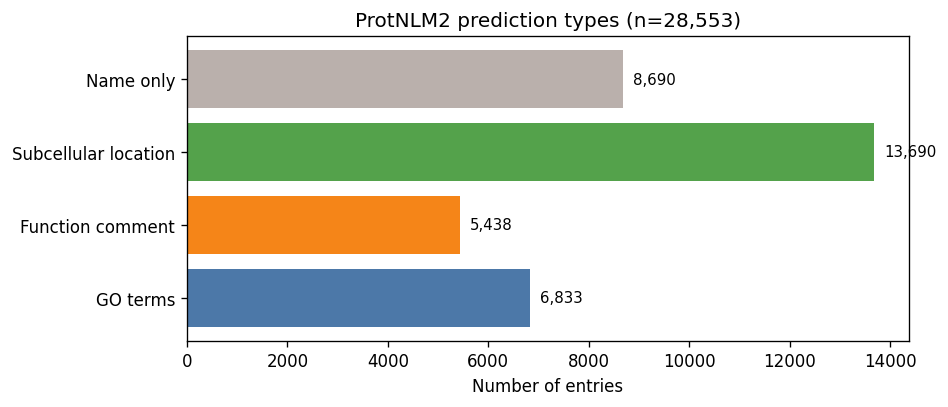

```python
fig, ax = plt.subplots(figsize=(8, 3.5))
cats = ["has_go", "has_function", "has_subcell", "name_only"]
labels = ["GO terms", "Function comment", "Subcellular location", "Name only"]
vals = [entries[c].sum() for c in cats]
ax.barh(labels, vals, color=["#4c78a8", "#f58518", "#54a24b", "#bab0ac"])
ax.set_xlabel("Number of entries")
ax.set_title("ProtNLM2 prediction types (n=28,553)")
for i, v in enumerate(vals):
    ax.text(v + 200, i, f"{v:,}", va="center", fontsize=9)
plt.tight_layout()
plt.show()
```

### Protein name types

ProtNLM2 assigns either a `recommendedName` (high-confidence, informative name) or a `submittedName` (lower-confidence, often echoing the original submission). About 79% receive recommended names.

```python
entries["name_type"].value_counts().to_frame("count")
```

| name_type | count |
| --- | --- |
| recommended | 22467 |
| submitted | 6086 |

### Swiss-Prot vs TrEMBL breakdown

The XML uses placeholder metadata, so we queried the UniProt REST API to determine the current reviewed status of each accession. This tells us how many of ProtNLM2's predictions target well-characterized (Swiss-Prot) vs uncharacterized (TrEMBL) proteins.

```
Swiss-Prot (reviewed): 1,094 (3.8%)
TrEMBL (unreviewed):   27,459 (96.2%)

Prediction richness by review status:
```

| reviewed | n_entries | pct_go | pct_function | pct_subcell | pct_name_only |
| --- | --- | --- | --- | --- | --- |
| TrEMBL | 27459 | 23.4 | 18.8 | 48.2 | 30.7 |
| Swiss-Prot | 1094 | 37.4 | 26.4 | 42.5 | 24.2 |

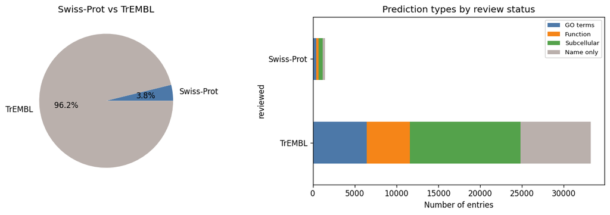

```python
status_path = DATA / "reviewed_status.tsv"
if status_path.exists():
    status = pd.read_csv(status_path, sep="\t")
    entries = entries.merge(status, on="accession", how="left")

    sp_counts = entries["reviewed"].value_counts()
    sp_total = sp_counts.get(True, 0)
    tr_total = sp_counts.get(False, 0)
    print(f"Swiss-Prot (reviewed): {sp_total:,} ({sp_total/len(entries)*100:.1f}%)")
    print(f"TrEMBL (unreviewed):   {tr_total:,} ({tr_total/len(entries)*100:.1f}%)")

    # Breakdown by prediction richness
    review_summary = entries.groupby("reviewed").agg(
        n_entries=("accession", "count"),
        pct_go=("has_go", "mean"),
        pct_function=("has_function", "mean"),
        pct_subcell=("has_subcell", "mean"),
        pct_name_only=("name_only", "mean"),
    )
    review_summary.index = review_summary.index.map({True: "Swiss-Prot", False: "TrEMBL"})
    for col in ["pct_go", "pct_function", "pct_subcell", "pct_name_only"]:
        review_summary[col] = (review_summary[col] * 100).round(1)
    print("\nPrediction richness by review status:")
    display(review_summary)

    # Chart
    fig, axes = plt.subplots(1, 2, figsize=(12, 4))

    # Pie
    axes[0].pie([sp_total, tr_total], labels=["Swiss-Prot", "TrEMBL"],
                autopct="%1.1f%%", colors=["#4c78a8", "#bab0ac"])
    axes[0].set_title("Swiss-Prot vs TrEMBL")

    # Stacked: prediction types by review status
    rev_pred = entries.groupby("reviewed").agg(
        has_go=("has_go", "sum"), has_function=("has_function", "sum"),
        has_subcell=("has_subcell", "sum"), name_only=("name_only", "sum"),
    )
    rev_pred.index = rev_pred.index.map({True: "Swiss-Prot", False: "TrEMBL"})
    rev_pred.plot.barh(stacked=True, ax=axes[1],
                       color=["#4c78a8", "#f58518", "#54a24b", "#bab0ac"])
    axes[1].set_xlabel("Number of entries")
    axes[1].set_title("Prediction types by review status")
    axes[1].legend(["GO terms", "Function", "Subcellular", "Name only"], fontsize=8)

    plt.tight_layout()
    plt.show()
else:
    print("reviewed_status.tsv not yet available — run fetch reviewed status")
```

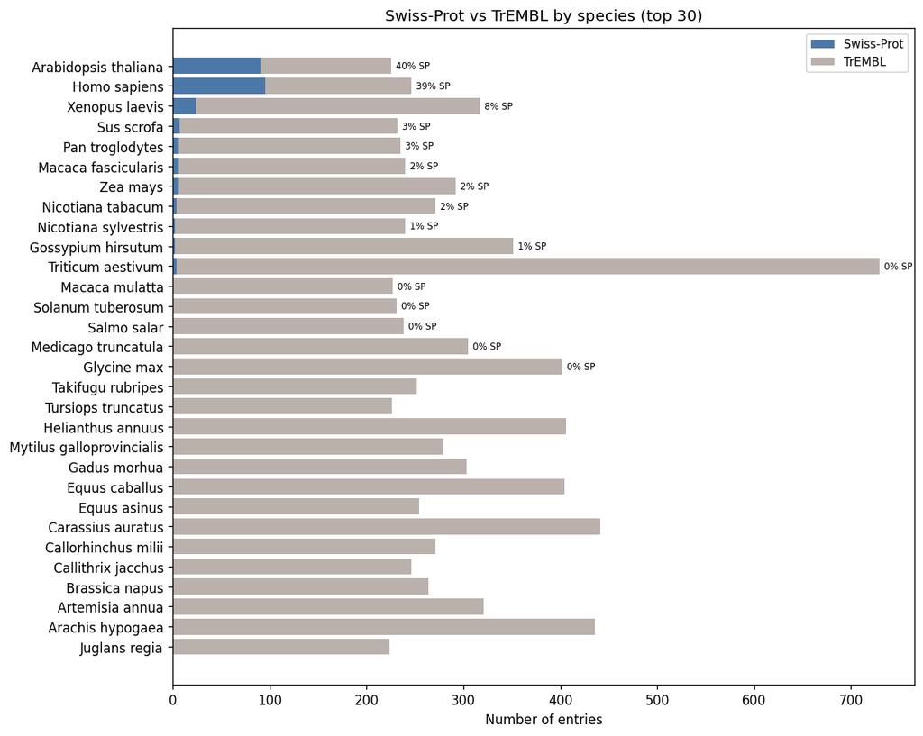

```
Swiss-Prot fraction by taxonomic group:
```

| broad_group | n_entries | n_swissprot | n_trembl | pct_swissprot |
| --- | --- | --- | --- | --- |
| Virus | 43 | 15 | 28 | 34.9 |
| Archaeon | 257 | 47 | 210 | 18.3 |
| Bacterium | 2524 | 316 | 2208 | 12.5 |
| Fungus | 1525 | 122 | 1403 | 8.0 |
| Nematode | 228 | 18 | 210 | 7.9 |
| Amphibian | 557 | 33 | 524 | 5.9 |
| Other | 351 | 17 | 334 | 4.8 |
| Mammal | 6927 | 296 | 6631 | 4.3 |
| Insect | 1146 | 37 | 1109 | 3.2 |
| Ray-finned fish | 1621 | 27 | 1594 | 1.7 |
| Land plant | 9518 | 149 | 9369 | 1.6 |
| Bird | 918 | 14 | 904 | 1.5 |
| Green alga | 91 | 1 | 90 | 1.1 |
| Alveolate | 374 | 1 | 373 | 0.3 |
| Other animal | 690 | 1 | 689 | 0.1 |
| Other arthropod | 504 | 0 | 504 | 0.0 |
| Stramenopile | 129 | 0 | 129 | 0.0 |
| Mollusc | 279 | 0 | 279 | 0.0 |
| Euglenozoan | 162 | 0 | 162 | 0.0 |
| Cartilaginous fish | 271 | 0 | 271 | 0.0 |
| Other vertebrate | 438 | 0 | 438 | 0.0 |

```python
if "reviewed" in entries.columns and "organism" in entries.columns:
    # By species (top 30 by total entries)
    top_species = entries["organism"].value_counts().head(30).index
    sp_review = entries[entries["organism"].isin(top_species)].groupby("organism")["reviewed"].agg(
        n_entries="count",
        n_swissprot="sum",
    )
    sp_review["n_trembl"] = sp_review["n_entries"] - sp_review["n_swissprot"]
    sp_review["pct_swissprot"] = (sp_review["n_swissprot"] / sp_review["n_entries"] * 100).round(1)
    sp_review = sp_review.sort_values("pct_swissprot", ascending=True)

    fig, ax = plt.subplots(figsize=(10, 8))
    ax.barh(sp_review.index, sp_review["n_swissprot"], label="Swiss-Prot", color="#4c78a8")
    ax.barh(sp_review.index, sp_review["n_trembl"], left=sp_review["n_swissprot"],
            label="TrEMBL", color="#bab0ac")
    ax.set_xlabel("Number of entries")
    ax.set_title("Swiss-Prot vs TrEMBL by species (top 30)")
    ax.legend(fontsize=9)
    for i, (_, row) in enumerate(sp_review.iterrows()):
        if row["n_swissprot"] > 0:
            ax.text(row["n_entries"] + 5, i, f'{row["pct_swissprot"]:.0f}% SP', va="center", fontsize=7)
    plt.tight_layout()
    plt.show()

    # By broad taxonomic group
    group_review = entries.groupby("broad_group")["reviewed"].agg(
        n_entries="count", n_swissprot="sum",
    )
    group_review["n_trembl"] = group_review["n_entries"] - group_review["n_swissprot"]
    group_review["pct_swissprot"] = (group_review["n_swissprot"] / group_review["n_entries"] * 100).round(1)
    group_review = group_review.sort_values("pct_swissprot", ascending=True)

    print("Swiss-Prot fraction by taxonomic group:")
    display(group_review.sort_values("pct_swissprot", ascending=False))
```

## Species and taxonomic breakdown

Species were resolved by batch-querying the UniProt REST API for each accession. Broad taxonomic groups (Mammal, Land plant, Ray-finned fish, etc.) were assigned by fetching NCBI lineages via the UniProt taxonomy endpoint and matching against major clades.

```python
species_counts = entries["organism"].value_counts()
print(f"Unique species: {species_counts.shape[0]}")
print(f"\nTop 30 species:")
display(species_counts.head(30).to_frame("count"))
```

```
Unique species: 440

Top 30 species:
```

| organism | count |
| --- | --- |
| Triticum aestivum | 729 |
| Carassius auratus | 441 |
| Arachis hypogaea | 436 |
| Helianthus annuus | 406 |
| Equus caballus | 404 |
| Glycine max | 402 |
| Gossypium hirsutum | 351 |
| Artemisia annua | 321 |
| Xenopus laevis | 317 |
| Medicago truncatula | 305 |
| Gadus morhua | 303 |
| Zea mays | 292 |
| Mytilus galloprovincialis | 279 |
| Nicotiana tabacum | 271 |
| Callorhinchus milii | 271 |
| Brassica napus | 264 |
| Equus asinus | 254 |
| Takifugu rubripes | 252 |
| Homo sapiens | 246 |
| Callithrix jacchus | 246 |
| Macaca fascicularis | 240 |
| Nicotiana sylvestris | 240 |
| Salmo salar | 238 |
| Pan troglodytes | 235 |
| Sus scrofa | 232 |
| Solanum tuberosum | 231 |
| Macaca mulatta | 227 |
| Tursiops truncatus | 226 |
| Arabidopsis thaliana | 225 |
| Juglans regia | 224 |

### Top 20 species, colored by taxonomic group

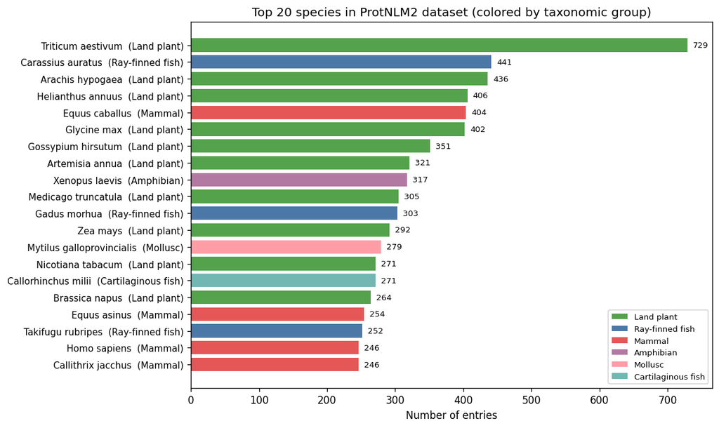

```python
GROUP_COLORS = {
    "Land plant": "#54a24b",
    "Mammal": "#e45756",
    "Ray-finned fish": "#4c78a8",
    "Cartilaginous fish": "#72b7b2",
    "Bird": "#eeca3b",
    "Amphibian": "#b279a2",
    "Other vertebrate": "#9d755d",
    "Insect": "#f58518",
    "Mollusc": "#ff9da6",
    "Nematode": "#d67195",
    "Fungus": "#9467bd",
    "Bacterium": "#bab0ac",
    "Other animal": "#d4a6c8",
}

top20 = species_counts.head(20)
top20_df = top20.to_frame("count").reset_index()
top20_df.columns = ["organism", "count"]

# Merge broad_group
org_group = entries[["organism", "broad_group"]].drop_duplicates("organism")
top20_df = top20_df.merge(org_group, on="organism", how="left")
top20_df["color"] = top20_df["broad_group"].map(GROUP_COLORS).fillna("#bab0ac")

fig, ax = plt.subplots(figsize=(10, 6))
bars = ax.barh(range(len(top20_df)), top20_df["count"], color=top20_df["color"])
ax.set_yticks(range(len(top20_df)))
ax.set_yticklabels([f"{row.organism}  ({row.broad_group})" for row in top20_df.itertuples()], fontsize=9)
ax.invert_yaxis()
ax.set_xlabel("Number of entries")
ax.set_title("Top 20 species in ProtNLM2 dataset (colored by taxonomic group)")
for i, v in enumerate(top20_df["count"]):
    ax.text(v + 8, i, str(v), va="center", fontsize=8)

# Legend
from matplotlib.patches import Patch
groups_in_chart = top20_df["broad_group"].unique()
handles = [Patch(facecolor=GROUP_COLORS.get(g, "#bab0ac"), label=g) for g in groups_in_chart if pd.notna(g)]
ax.legend(handles=handles, loc="lower right", fontsize=8)

plt.tight_layout()
plt.show()
```

### Entries by broad taxonomic group

Aggregating across all 440 species into broad taxonomic groups shows the overall composition of the dataset.

| broad_group | count |
| --- | --- |
| Land plant | 9518 |
| Mammal | 6927 |
| Bacterium | 2524 |
| Ray-finned fish | 1621 |
| Fungus | 1525 |
| Insect | 1146 |
| Bird | 918 |
| Other animal | 690 |
| Amphibian | 557 |
| Other arthropod | 504 |
| Other vertebrate | 438 |
| Alveolate | 374 |
| Other | 351 |
| Mollusc | 279 |
| Cartilaginous fish | 271 |
| Archaeon | 257 |
| Nematode | 228 |
| Euglenozoan | 162 |
| Stramenopile | 129 |
| Green alga | 91 |
| Virus | 43 |

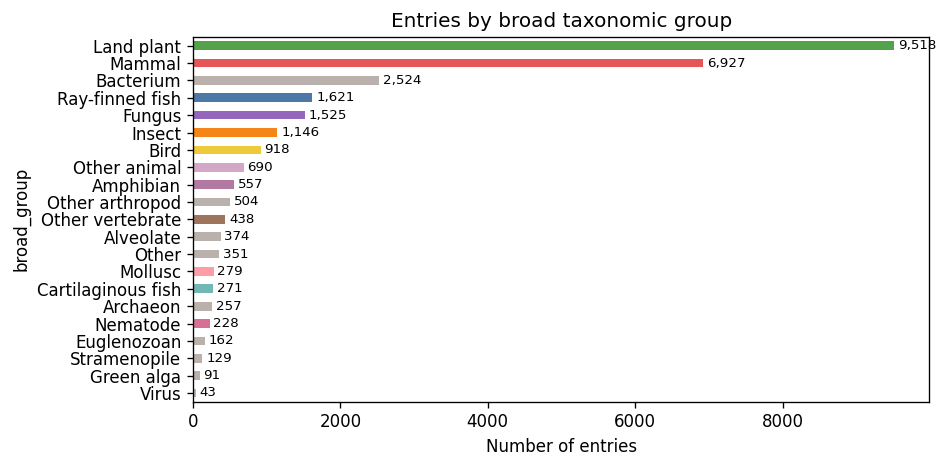

```python
group_counts = entries["broad_group"].value_counts()
display(group_counts.to_frame("count"))

fig, ax = plt.subplots(figsize=(8, 4))
colors = [GROUP_COLORS.get(g, "#bab0ac") for g in group_counts.index]
group_counts.plot.barh(ax=ax, color=colors)
ax.invert_yaxis()
ax.set_xlabel("Number of entries")
ax.set_title("Entries by broad taxonomic group")
for i, v in enumerate(group_counts):
    ax.text(v + 50, i, f"{v:,}", va="center", fontsize=8)
plt.tight_layout()
plt.show()
```

### Prediction types by taxonomic group (stacked)

Do certain taxonomic groups get richer predictions? This stacked bar chart shows how many entries in each group have GO terms, function comments, subcellular locations, or just a protein name. Note that categories overlap — an entry can have both GO terms and a subcellular location — so the stacked chart shows the *fraction* of entries in each group that have each prediction type.

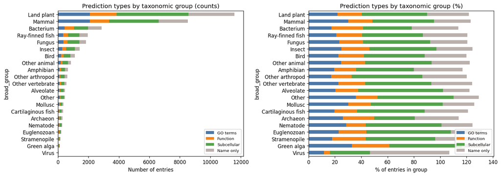

```python
pred_by_group = entries.groupby("broad_group").agg(
    n_entries=("accession", "count"),
    has_go=("has_go", "sum"),
    has_function=("has_function", "sum"),
    has_subcell=("has_subcell", "sum"),
    name_only=("name_only", "sum"),
).sort_values("n_entries", ascending=True)

# As percentages
pct = pred_by_group[["has_go", "has_function", "has_subcell", "name_only"]].div(
    pred_by_group["n_entries"], axis=0
) * 100

fig, axes = plt.subplots(1, 2, figsize=(14, 5))

# Left: stacked counts
pred_by_group[["has_go", "has_function", "has_subcell", "name_only"]].plot.barh(
    stacked=True, ax=axes[0],
    color=["#4c78a8", "#f58518", "#54a24b", "#bab0ac"]
)
axes[0].set_xlabel("Number of entries")
axes[0].set_title("Prediction types by taxonomic group (counts)")
axes[0].legend(["GO terms", "Function", "Subcellular", "Name only"], fontsize=8, loc="lower right")

# Right: percentages
pct.plot.barh(
    stacked=True, ax=axes[1],
    color=["#4c78a8", "#f58518", "#54a24b", "#bab0ac"]
)
axes[1].set_xlabel("% of entries in group")
axes[1].set_title("Prediction types by taxonomic group (%)")
axes[1].legend(["GO terms", "Function", "Subcellular", "Name only"], fontsize=8, loc="lower right")

plt.tight_layout()
plt.show()
```

The XML file is a **post-processed** export: after ProtNLM2 generates a free-text prediction, a downstream pipeline cross-references that prediction against known databases to check whether it matches something in UniProt's existing annotation vocabulary. The `match_location` field records *which database* the predicted text was validated against:

| `match_location` | What it means | Example `match_text` |
| --- | --- | --- |
| `domain` | Predicted name matched a known UniProt domain description | `WRKY` |
| `PANTHER` | Matched a PANTHER family/subfamily ID | `PTHR22654` |
| `GO` | Matched a GO term ID | `GO:0005737` |
| `keyword` | Matched a UniProt keyword ID | `KW-0472` |
| `recommended_protein_name` | Matched an existing recommended protein name | `Aldehyde dehydrogenase` |
| `InterPro` | Matched an InterPro accession | `IPR000225` |

### Prediction richness by species

For species with at least 50 entries, what fraction of their proteins get each type of prediction? Sorted by % with GO terms.

```python
sp_groups = entries.groupby("organism").filter(lambda g: len(g) >= 50).groupby("organism")
richness = sp_groups.agg(
    n_entries=("accession", "count"),
    pct_go=("has_go", "mean"),
    pct_function=("has_function", "mean"),
    pct_subcell=("has_subcell", "mean"),
    mean_go=("n_go", "mean"),
).sort_values("pct_go", ascending=False)
richness[["pct_go", "pct_function", "pct_subcell"]] = (
    richness[["pct_go", "pct_function", "pct_subcell"]] * 100
).round(1)
richness["mean_go"] = richness["mean_go"].round(2)
display(richness.head(30))
```

| organism | n_entries | pct_go | pct_function | pct_subcell | mean_go |
| --- | --- | --- | --- | --- | --- |
| Emericella nidulans (strain FGSC A4 / ATCC 38163 / CBS 112.46 / NRRL 194 / M139) | 53 | 49.1 | 20.8 | 34.0 | 0.62 |
| Trichomonas vaginalis (strain ATCC PRA-98 / G3) | 128 | 45.3 | 15.6 | 53.1 | 0.74 |
| Equus asinus | 254 | 42.1 | 18.1 | 49.6 | 0.67 |
| Bos taurus | 152 | 42.1 | 15.8 | 40.1 | 0.62 |
| Oryzias latipes | 172 | 41.9 | 24.4 | 39.5 | 0.66 |
| Canis lupus familiaris | 197 | 40.1 | 18.8 | 38.1 | 0.91 |
| Spinacia oleracea | 116 | 39.7 | 21.6 | 47.4 | 0.53 |
| Macaca mulatta | 227 | 39.6 | 20.3 | 48.9 | 0.72 |
| Drosophila melanogaster | 124 | 38.7 | 16.1 | 50.0 | 0.56 |
| Gorilla gorilla gorilla | 223 | 37.2 | 20.2 | 43.9 | 0.64 |
| Equus caballus | 404 | 36.4 | 12.9 | 46.5 | 0.70 |
| Ictidomys tridecemlineatus | 149 | 36.2 | 24.8 | 43.6 | 0.54 |
| Panthera leo | 175 | 36.0 | 16.0 | 45.1 | 0.64 |
| Ciona intestinalis | 70 | 35.7 | 22.9 | 50.0 | 0.53 |
| Pan troglodytes | 235 | 35.3 | 15.7 | 46.4 | 0.49 |
| Streptomyces coelicolor (strain ATCC BAA-471 / A3(2) / M145) | 51 | 35.3 | 25.5 | 29.4 | 0.39 |
| Ornithorhynchus anatinus | 176 | 35.2 | 16.5 | 42.6 | 0.60 |
| Vitis vinifera | 134 | 35.1 | 23.9 | 46.3 | 0.51 |
| Tribolium castaneum | 80 | 35.0 | 20.0 | 51.2 | 0.48 |
| Rattus norvegicus | 198 | 34.8 | 22.7 | 42.4 | 0.48 |
| Sus scrofa | 232 | 34.5 | 19.4 | 50.9 | 0.53 |
| Danio rerio | 181 | 33.7 | 19.9 | 42.0 | 0.52 |
| Cavia porcellus | 146 | 33.6 | 21.2 | 46.6 | 0.55 |
| Homo sapiens | 246 | 33.3 | 19.5 | 47.2 | 0.47 |
| Macaca fascicularis | 240 | 33.3 | 21.7 | 52.9 | 0.72 |
| Manduca sexta | 100 | 33.0 | 22.0 | 58.0 | 0.52 |
| Capsicum annuum | 186 | 32.3 | 21.5 | 47.8 | 0.42 |
| Chlamydomonas reinhardtii | 62 | 32.3 | 30.6 | 54.8 | 0.39 |
| Neurospora crassa (strain ATCC 24698 / 74-OR23-1A / CBS 708.71 / DSM 1257 / FGSC 987) | 57 | 31.6 | 10.5 | 43.9 | 0.44 |
| Trypanosoma brucei brucei (strain 927/4 GUTat10.1) | 51 | 31.4 | 19.6 | 76.5 | 0.33 |

## Model confidence scores

```
Evidence blocks with scores: 56,048
               count      mean       std   min   25%   50%   75%  max
model_score  56048.0  0.634915  0.302964  0.05  0.37  0.68  0.94  1.0
```

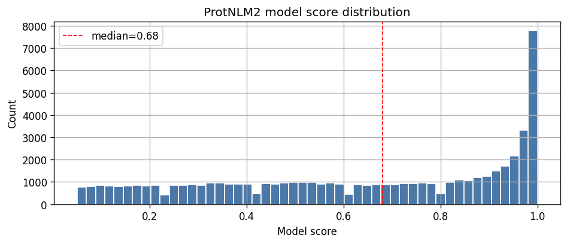

```python
scores = evidence["model_score"].dropna()
print(f"Evidence blocks with scores: {len(scores):,}")
print(scores.describe().to_frame().T)

fig, ax = plt.subplots(figsize=(8, 3.5))
scores.hist(bins=50, ax=ax, color="#4c78a8", edgecolor="white")
ax.set_xlabel("Model score")
ax.set_ylabel("Count")
ax.set_title("ProtNLM2 model score distribution")
ax.axvline(scores.median(), color="red", ls="--", lw=1, label=f"median={scores.median():.2f}")
ax.legend()
plt.tight_layout()
plt.show()
```

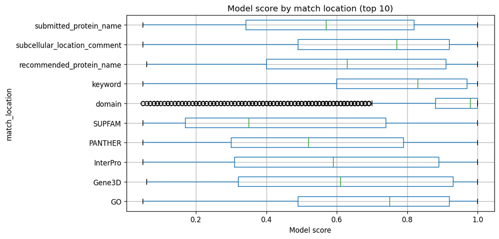

```python
ev_with_loc = evidence.dropna(subset=["match_location", "model_score"])
top_locs = ev_with_loc["match_location"].value_counts().head(10).index

fig, ax = plt.subplots(figsize=(10, 5))
ev_with_loc[ev_with_loc["match_location"].isin(top_locs)].boxplot(
    column="model_score", by="match_location", ax=ax, vert=False
)
ax.set_xlabel("Model score")
ax.set_title("Model score by match location (top 10)")
fig.suptitle("")
plt.tight_layout()
plt.show()
```

### Match type breakdown

ProtNLM2 uses three match types:

- **exact_sanitized**: prediction exactly matches a database entry (after normalization)
- **hydrated**: GO/keyword IDs were resolved to their full labels
- **substring**: partial match to a longer database text

Evidence blocks from phmmer/tmalign sequence searches have no match_type (they use sequence similarity scores instead).

```python
evidence["match_type"].value_counts(dropna=False).to_frame("count")
```

| match_type | count |
| --- | --- |
| NaN | 24650 |
| exact_sanitized | 21085 |
| hydrated | 7200 |
| substring | 3113 |

## GO term predictions

About 24% of entries (6,833) receive GO term predictions. These span 2,006 unique GO terms. The most frequently predicted terms are very generic (nucleus, membrane, DNA binding) — a pattern worth investigating for frequency bias.

```python
go_preds = predictions[predictions["pred_type"] == "GO"]
print(f"Total GO predictions: {len(go_preds):,}")
print(f"Unique GO terms: {go_preds['pred_id'].nunique()}")

top_go = go_preds["pred_label"].value_counts().head(20)
display(top_go.to_frame("count"))

# Aspect breakdown (GO term labels start with C:, F:, or P:)
go_preds = go_preds.copy()
go_preds["aspect"] = go_preds["pred_label"].str[0]
print("\nGO aspect distribution:")
display(go_preds["aspect"].value_counts().to_frame("count"))
```

```
Total GO predictions: 10,550
Unique GO terms: 2006
```

| pred_label | count |
| --- | --- |
| C:nucleus | 530 |
| C:membrane | 529 |
| F:DNA binding | 331 |
| C:extracellular region | 229 |
| C:cytoplasm | 201 |
| P:phosphorylation | 133 |
| C:nucleoplasm | 132 |
| P:regulation of transcription by RNA polymerase II | 113 |
| F:oxidoreductase activity | 109 |
| F:metal ion binding | 109 |
| C:ribosome | 105 |
| C:ribonucleoprotein complex | 103 |
| P:regulation of DNA-templated transcription | 103 |
| P:protein phosphorylation | 103 |
| F:DNA-binding transcription factor activity | 84 |
| F:RNA binding | 82 |
| P:proteolysis | 80 |
| F:kinase activity | 76 |
| F:nucleic acid binding | 74 |
| F:catalytic activity | 72 |

```
GO aspect distribution:
```

| aspect | count |
| --- | --- |
| P | 3900 |
| F | 3492 |
| C | 3158 |

## Subcellular location predictions

Nearly half the entries (48%) get subcellular location predictions. Membrane and nucleus dominate.

```
Total subcellular location predictions: 16,986
```

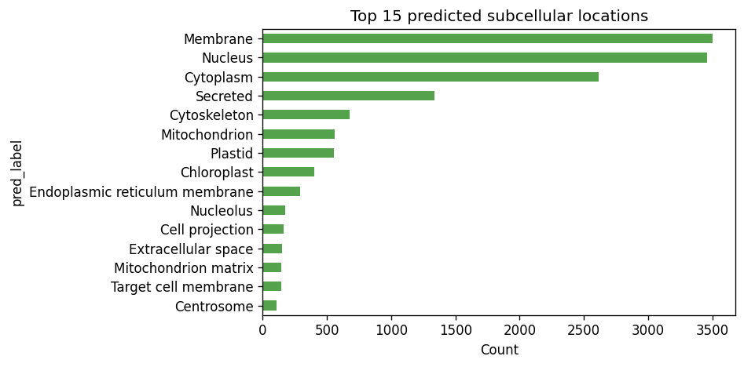

```python
subcell_preds = predictions[predictions["pred_type"] == "subcellular_location"]
print(f"Total subcellular location predictions: {len(subcell_preds):,}")

top_locs = subcell_preds["pred_label"].value_counts().head(15)
fig, ax = plt.subplots(figsize=(8, 4))
top_locs.plot.barh(ax=ax, color="#54a24b")
ax.invert_yaxis()
ax.set_xlabel("Count")
ax.set_title("Top 15 predicted subcellular locations")
plt.tight_layout()
plt.show()
```

## Evidence methods

ProtNLM2 evidence blocks come from three methods:

- **string_match** (56%): The predicted text matches a known database entry (domain, GO, PANTHER, etc.)
- **phmmer** (40%): Sequence search against characterized proteins (reports accession + bit score)
- **tmalign** (4%): Structure-based alignment (reports TM-scores for both chains)

String matches tend to have higher confidence; tmalign scores are more uniformly distributed.

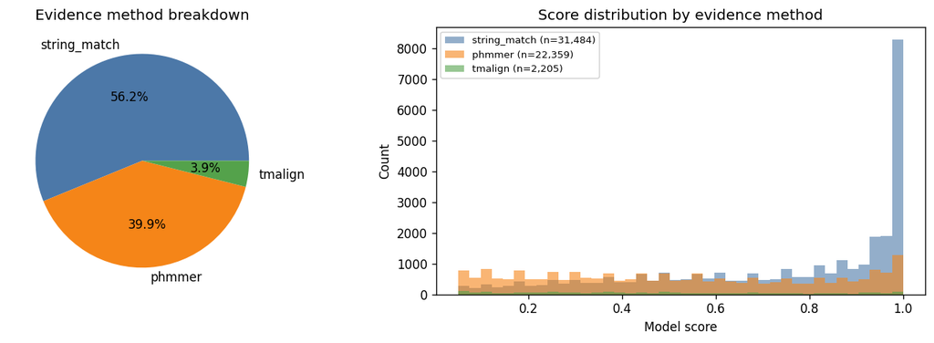

```python
evidence["method"] = "string_match"
evidence.loc[evidence["phmmer_accession"].notna(), "method"] = "phmmer"
evidence.loc[evidence["tmalign_accession"].notna(), "method"] = "tmalign"

method_counts = evidence["method"].value_counts()

fig, axes = plt.subplots(1, 2, figsize=(12, 4))

# Pie chart
method_counts.plot.pie(ax=axes[0], autopct="%1.1f%%",
                       colors=["#4c78a8", "#f58518", "#54a24b"])
axes[0].set_ylabel("")
axes[0].set_title("Evidence method breakdown")

# Score distributions
for method, color in [("string_match", "#4c78a8"), ("phmmer", "#f58518"), ("tmalign", "#54a24b")]:
    subset = evidence[evidence["method"] == method]["model_score"].dropna()
    axes[1].hist(subset, bins=40, alpha=0.6, color=color, label=f"{method} (n={len(subset):,})")
axes[1].set_xlabel("Model score")
axes[1].set_ylabel("Count")
axes[1].set_title("Score distribution by evidence method")
axes[1].legend(fontsize=8)

plt.tight_layout()
plt.show()
```

## Overlap with AIGR curated reviews

How many of the 28K ProtNLM2 entries overlap with our existing expert-curated gene reviews?

```python
import subprocess

repo_root = Path("../..")
review_files = list(repo_root.glob("genes/*/*-ai-review.yaml"))
result = subprocess.run(
    ["grep", "-rh", "^id:", *[str(f) for f in review_files]],
    capture_output=True, text=True
)
reviewed_ids = {line.split(":", 1)[1].strip() for line in result.stdout.strip().split("\n") if line}
protnlm_ids = set(entries["accession"])

overlap = reviewed_ids & protnlm_ids
print(f"AIGR reviewed genes: {len(reviewed_ids):,}")
print(f"ProtNLM2 entries: {len(protnlm_ids):,}")
print(f"Overlap: {len(overlap)}")
if overlap:
    print(f"\nOverlapping accessions:")
    cols = ["accession", "protein_name", "n_go", "n_function", "n_subcell"]
    if "organism" in entries.columns:
        cols.insert(2, "organism")
    if "broad_group" in entries.columns:
        cols.insert(3, "broad_group")
    display(entries[entries["accession"].isin(overlap)][cols])
```

```
AIGR reviewed genes: 0
ProtNLM2 entries: 28,553
Overlap: 0
```

## Validation: ProtNLM2 GO predictions vs curated GOA annotations

The summary statistics above describe the dataset as a whole. But how good are the predictions? To evaluate, we compare ProtNLM2's GO term predictions against curated GO annotations from the GOA database, using the **`isa_partof_closure`** table in DuckDB to capture hierarchical relationships in the ontology.

| Species | DuckDB source | Why chosen |
| --- | --- | --- |
| **Human** | `goa_human.ddb` | Best-annotated proteome; baseline for comparison |
| **X. laevis** | `goa_xenopus.ddb` | Allotetraploid frog; many duplicated genes (ohnologs) with potential for paralog divergence |
| **X. tropicalis** | `goa_xenopus.ddb` | Diploid frog; simpler genome, comparison point for laevis paralogs |
| **Arabidopsis thaliana** | `goa_uniprot_gcrp.ddb` | Well-studied plant; many proteins with only ND annotations |
| **Mouse** | `goa_mouse.ddb` | Well-annotated mammalian model organism; 710K GOA annotations |
| **Wheat** (*T. aestivum*) | `goa_wheat.ddb` | Top plant species by entry count (729); large GOA with 512K annotations |
| **Streptomyces coelicolor** | `bacteria.ddb` | Model actinobacterium; small sample but good GOA coverage |

### Match category definitions

For each ProtNLM2 GO prediction on a protein that exists in GOA, we classify the relationship using the ontology closure:

| Category | Code | Definition |
| --- | --- | --- |
| **Exact** | `EXACT` | ProtNLM2 predicted the *same GO term* that exists in GOA for this protein |
| **Less specific** | `LESS_SPECIFIC` | ProtNLM2 predicted a *strict ancestor* of a GOA term — not wrong, but redundant (e.g. predicts "membrane" when GOA has "plasma membrane") |
| **More specific** | `MORE_SPECIFIC` | ProtNLM2 predicted a *strict descendant* of a GOA term — potentially novel and more informative |
| **No overlap** | `NO_OVERLAP` | Protein is in GOA but the predicted term has no ancestor/descendant relationship to any existing annotation — could be novel or incorrect |
| **Not in GCRP** | `NOT_IN_GCRP` | Protein is absent from the GCRP (Gene Centric Reference Proteome) subset of GOA — may have annotations in full GOA |

### Cross-species summary

```
Human: 115 GO predictions, 82 proteins
Mouse: 84 GO predictions, 46 proteins
X. laevis: 113 GO predictions, 61 proteins
```

```
X. tropicalis: 84 GO predictions, 36 proteins
```

```
Arabidopsis: 75 GO predictions, 57 proteins
Wheat: 257 GO predictions, 192 proteins
```

```
S. coelicolor: 20 GO predictions, 18 proteins
```

| species match_category | Arabidopsis | Human | Mouse | S. coelicolor | Wheat | X. laevis | X. tropicalis |
| --- | --- | --- | --- | --- | --- | --- | --- |
| EXACT | 23 | 40 | 16 | 11 | 76 | 22 | 28 |
| LESS_SPECIFIC | 15 | 10 | 9 | 0 | 19 | 8 | 1 |
| MORE_SPECIFIC | 13 | 0 | 4 | 1 | 5 | 11 | 8 |
| NO_OVERLAP | 9 | 2 | 9 | 1 | 51 | 20 | 15 |
| NOT_IN_GCRP | 15 | 63 | 46 | 7 | 106 | 52 | 32 |

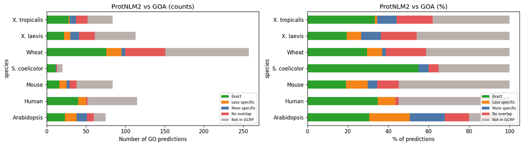

```python
import duckdb

COMPARE_SPECIES = [
    ("Human", 9606, Path.home() / "repos/go-db/db/goa_human.ddb", None),
    ("Mouse", 10090, Path.home() / "repos/go-db/db/goa_mouse.ddb", None),
    ("X. laevis", 8355, Path.home() / "repos/go-db/db/goa_xenopus.ddb", "taxon:8355"),
    ("X. tropicalis", 8364, Path.home() / "repos/go-db/db/goa_xenopus.ddb", "taxon:8364"),
    ("Arabidopsis", 3702, Path.home() / "repos/go-db/db/goa_uniprot_gcrp.ddb", "taxon:3702"),
    ("Wheat", 4565, Path.home() / "repos/go-db/db/goa_wheat.ddb", None),
    ("S. coelicolor", 100226, Path.home() / "repos/go-db/db/bacteria.ddb", "taxon:100226"),
]

# Categories in display order
CAT_ORDER = ["EXACT", "LESS_SPECIFIC", "MORE_SPECIFIC", "NO_OVERLAP", "NOT_IN_GCRP"]
CAT_LABELS = ["Exact", "Less specific", "More specific", "No overlap", "Not in GCRP"]
CAT_COLORS = ["#2ca02c", "#f58518", "#4c78a8", "#e45756", "#bab0ac"]

COMPARISON_SQL = """
    CREATE TEMP TABLE protnlm AS
    SELECT * FROM read_csv_auto('{csv_path}');

    WITH in_goa AS (
        SELECT DISTINCT db_object_id FROM gaf_association {taxon_filter}
    ),
    -- EXACT: predicted term is literally in GOA for this protein
    exact AS (
        SELECT DISTINCT p.accession, p.pred_id
        FROM protnlm p
        INNER JOIN gaf_association g ON p.accession = g.db_object_id AND p.pred_id = g.ontology_class_ref
        {taxon_where}
    ),
    -- LESS_SPECIFIC: predicted term is a strict ancestor of a GOA term
    less_specific AS (
        SELECT DISTINCT p.accession, p.pred_id
        FROM protnlm p
        INNER JOIN gaf_association g ON p.accession = g.db_object_id
        INNER JOIN isa_partof_closure ipc ON g.ontology_class_ref = ipc.subject
        WHERE ipc.object = p.pred_id AND g.ontology_class_ref != p.pred_id
        {taxon_and}
    ),
    -- MORE_SPECIFIC: predicted term is a strict descendant of a GOA term
    more_specific AS (
        SELECT DISTINCT p.accession, p.pred_id
        FROM protnlm p
        INNER JOIN gaf_association g ON p.accession = g.db_object_id
        INNER JOIN isa_partof_closure ipc ON p.pred_id = ipc.subject
        WHERE ipc.object = g.ontology_class_ref AND g.ontology_class_ref != p.pred_id
        {taxon_and}
    )
    SELECT
        CASE
            WHEN e.pred_id IS NOT NULL THEN 'EXACT'
            WHEN ls.pred_id IS NOT NULL THEN 'LESS_SPECIFIC'
            WHEN ms.pred_id IS NOT NULL THEN 'MORE_SPECIFIC'
            WHEN ig.db_object_id IS NULL THEN 'NOT_IN_GCRP'
            ELSE 'NO_OVERLAP'
        END AS match_category,
        COUNT(*) AS n_predictions,
        COUNT(DISTINCT p.accession) AS n_proteins
    FROM protnlm p
    LEFT JOIN in_goa ig ON p.accession = ig.db_object_id
    LEFT JOIN exact e ON p.accession = e.accession AND p.pred_id = e.pred_id
    LEFT JOIN less_specific ls ON p.accession = ls.accession AND p.pred_id = ls.pred_id
    LEFT JOIN more_specific ms ON p.accession = ms.accession AND p.pred_id = ms.pred_id
    GROUP BY 1
    ORDER BY 2 DESC;
"""

DETAIL_SQL = """
    WITH in_goa AS (
        SELECT DISTINCT db_object_id FROM gaf_association {taxon_filter}
    ),
    exact AS (
        SELECT DISTINCT p.accession, p.pred_id
        FROM protnlm p
        INNER JOIN gaf_association g ON p.accession = g.db_object_id AND p.pred_id = g.ontology_class_ref
        {taxon_where}
    ),
    less_specific AS (
        SELECT DISTINCT ON (p.accession, p.pred_id) p.accession, p.pred_id,
               g.ontology_class_ref AS goa_match, gt.label AS goa_match_label
        FROM protnlm p
        INNER JOIN gaf_association g ON p.accession = g.db_object_id
        INNER JOIN isa_partof_closure ipc ON g.ontology_class_ref = ipc.subject
        INNER JOIN term_label gt ON g.ontology_class_ref = gt.id
        WHERE ipc.object = p.pred_id AND g.ontology_class_ref != p.pred_id
        {taxon_and}
    ),
    more_specific AS (
        SELECT DISTINCT ON (p.accession, p.pred_id) p.accession, p.pred_id,
               g.ontology_class_ref AS goa_match, gt.label AS goa_match_label
        FROM protnlm p
        INNER JOIN gaf_association g ON p.accession = g.db_object_id
        INNER JOIN isa_partof_closure ipc ON p.pred_id = ipc.subject
        INNER JOIN term_label gt ON g.ontology_class_ref = gt.id
        WHERE ipc.object = g.ontology_class_ref AND g.ontology_class_ref != p.pred_id
        {taxon_and}
    )
    SELECT
        p.accession,
        p.pred_id AS protnlm_term,
        pt.label AS protnlm_label,
        CASE
            WHEN e.pred_id IS NOT NULL THEN 'EXACT'
            WHEN ls.pred_id IS NOT NULL THEN 'LESS_SPECIFIC'
            WHEN ms.pred_id IS NOT NULL THEN 'MORE_SPECIFIC'
            WHEN ig.db_object_id IS NULL THEN 'NOT_IN_GCRP'
            ELSE 'NO_OVERLAP'
        END AS match_category,
        CASE WHEN e.pred_id IS NOT NULL THEN p.pred_id ELSE COALESCE(ls.goa_match, ms.goa_match, '') END AS closest_goa_term,
        CASE WHEN e.pred_id IS NOT NULL THEN pt.label ELSE COALESCE(ls.goa_match_label, ms.goa_match_label, '') END AS closest_goa_label
    FROM protnlm p
    LEFT JOIN term_label pt ON p.pred_id = pt.id
    LEFT JOIN in_goa ig ON p.accession = ig.db_object_id
    LEFT JOIN exact e ON p.accession = e.accession AND p.pred_id = e.pred_id
    LEFT JOIN less_specific ls ON p.accession = ls.accession AND p.pred_id = ls.pred_id
    LEFT JOIN more_specific ms ON p.accession = ms.accession AND p.pred_id = ms.pred_id
    ORDER BY match_category, p.accession;
"""

all_summaries = []
all_details = {}

for species_name, taxon_id, db_path, taxon_str in COMPARE_SPECIES:
    sp_accs = set(entries[entries["taxon_id"] == taxon_id]["accession"])
    sp_go = predictions[
        (predictions["pred_type"] == "GO") & (predictions["accession"].isin(sp_accs))
    ][["accession", "pred_id", "pred_label"]]
    csv_path = f"/tmp/protnlm_{species_name.lower().replace(' ', '_').replace('.', '')}_go.csv"
    sp_go.to_csv(csv_path, index=False)

    if taxon_str:
        taxon_filter = f"WHERE db_object_taxon = '{taxon_str}'"
        taxon_where = f"WHERE g.db_object_taxon = '{taxon_str}'"
        taxon_and = f"AND g.db_object_taxon = '{taxon_str}'"
    else:
        taxon_filter = taxon_where = taxon_and = ""

    con = duckdb.connect(str(db_path), read_only=True)
    summary = con.execute(COMPARISON_SQL.format(
        csv_path=csv_path, taxon_filter=taxon_filter,
        taxon_where=taxon_where, taxon_and=taxon_and
    )).fetchdf()
    summary["species"] = species_name
    all_summaries.append(summary)

    detail = con.execute(DETAIL_SQL.format(
        taxon_filter=taxon_filter, taxon_where=taxon_where, taxon_and=taxon_and
    )).fetchdf()
    all_details[species_name] = detail
    con.close()

    print(f"{species_name}: {len(sp_go)} GO predictions, {sp_go['accession'].nunique()} proteins")

combined = pd.concat(all_summaries, ignore_index=True)
pivot = combined.pivot_table(
    index="match_category", columns="species",
    values="n_predictions", fill_value=0, aggfunc="sum"
).reindex(CAT_ORDER)
display(pivot)

# Stacked bar chart
fig, axes = plt.subplots(1, 2, figsize=(14, 4))
pivot_t = pivot.T.reindex(columns=CAT_ORDER)
pivot_t.plot.barh(stacked=True, ax=axes[0], color=CAT_COLORS)
axes[0].set_xlabel("Number of GO predictions")
axes[0].set_title("ProtNLM2 vs GOA (counts)")
axes[0].legend(CAT_LABELS, fontsize=7, loc="lower right")

pct_pivot = pivot_t.div(pivot_t.sum(axis=1), axis=0) * 100
pct_pivot.plot.barh(stacked=True, ax=axes[1], color=CAT_COLORS)
axes[1].set_xlabel("% of predictions")
axes[1].set_title("ProtNLM2 vs GOA (%)")
axes[1].legend(CAT_LABELS, fontsize=7, loc="lower right")
plt.tight_layout()
plt.show()
```

### Comparison by GOA annotation source

The analysis above compares ProtNLM2 against *all* GOA annotations. But GOA is a mix of high-quality experimental annotations, computational pipelines, and phylogenetic inference. How does ProtNLM2 compare against specific automated pipelines that it might be replacing?

We repeat the closure-based comparison against three GOA subsets:

| GOA subset | Filter | What it captures |
| --- | --- | --- |
| **InterPro2GO** | `assigned_by = 'InterPro'` | Domain-based GO annotation via InterPro matches — the most direct comparison since ProtNLM2 also uses domain/family information |
| **IBA** | `evidence_type = 'IBA'` | Phylogenetic annotation from PAINT/GO_Central — orthology-based function transfer |
| **InterPro2GO + IBA** | Both combined | The union of the two major automated pipelines |

This tells us whether ProtNLM2 adds value beyond what existing automated methods already provide.

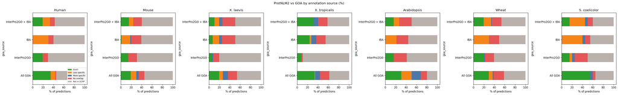

Human

| match_category goa_source | EXACT | LESS_SPECIFIC | MORE_SPECIFIC | NO_OVERLAP | NOT_IN_GCRP |
| --- | --- | --- | --- | --- | --- |
| All GOA | 40 | 10 | NaN | 2 | 63 |
| InterPro2GO | 22 | 0 | NaN | 12 | 81 |
| IBA | 0 | 35 | NaN | 11 | 69 |
| InterPro2GO + IBA | 22 | 16 | NaN | 11 | 66 |

Mouse

| match_category goa_source | EXACT | LESS_SPECIFIC | MORE_SPECIFIC | NO_OVERLAP | NOT_IN_GCRP |
| --- | --- | --- | --- | --- | --- |
| All GOA | 16 | 9 | 4 | 9 | 46 |
| InterPro2GO | 12 | 0 | 0 | 14 | 58 |
| IBA | 1 | 14 | 2 | 16 | 51 |
| InterPro2GO + IBA | 13 | 7 | 0 | 14 | 50 |

X. laevis

| match_category goa_source | EXACT | LESS_SPECIFIC | MORE_SPECIFIC | NO_OVERLAP | NOT_IN_GCRP |
| --- | --- | --- | --- | --- | --- |
| All GOA | 22 | 8 | 11 | 20 | 52 |
| InterPro2GO | 7 | 0 | 2 | 13 | 91 |
| IBA | 8 | 14 | 6 | 29 | 56 |
| InterPro2GO + IBA | 12 | 10 | 7 | 28 | 56 |

X. tropicalis

| match_category goa_source | EXACT | LESS_SPECIFIC | MORE_SPECIFIC | NO_OVERLAP | NOT_IN_GCRP |
| --- | --- | --- | --- | --- | --- |
| All GOA | 28 | 1 | 8 | 15 | 32 |
| InterPro2GO | 7 | 0 | 0 | 2 | 75 |
| IBA | 20 | 3 | 8 | 15 | 38 |
| InterPro2GO + IBA | 26 | 0 | 8 | 15 | 35 |

Arabidopsis

| match_category goa_source | EXACT | LESS_SPECIFIC | MORE_SPECIFIC | NO_OVERLAP | NOT_IN_GCRP |
| --- | --- | --- | --- | --- | --- |
| All GOA | 23 | 15 | 13 | 9 | 15 |
| InterPro2GO | 12 | 0 | 0 | 19 | 44 |
| IBA | 0 | 16 | 0 | 17 | 42 |
| InterPro2GO + IBA | 12 | 8 | 0 | 18 | 37 |

Wheat

| match_category goa_source | EXACT | LESS_SPECIFIC | MORE_SPECIFIC | NO_OVERLAP | NOT_IN_GCRP |
| --- | --- | --- | --- | --- | --- |
| All GOA | 76 | 19 | 5 | 51 | 106 |
| InterPro2GO | 50 | 0 | 7 | 44 | 156 |
| IBA | 0 | 77 | 1 | 49 | 130 |
| InterPro2GO + IBA | 50 | 37 | 3 | 48 | 119 |

S. coelicolor

| match_category goa_source | EXACT | LESS_SPECIFIC | MORE_SPECIFIC | NO_OVERLAP | NOT_IN_GCRP |
| --- | --- | --- | --- | --- | --- |
| All GOA | 11 | 0 | 1 | 1 | 7 |
| InterPro2GO | 3 | 1 | 1 | 5 | 10 |
| IBA | 0 | 8 | 1 | 2 | 9 |
| InterPro2GO + IBA | 3 | 6 | 1 | 2 | 8 |

```python
from IPython.display import display, Markdown

SOURCE_COMPARISON_SQL = """
    CREATE OR REPLACE TEMP TABLE protnlm AS
    SELECT * FROM read_csv_auto('{csv_path}');

    WITH goa_filtered AS (
        SELECT * FROM gaf_association
        {taxon_where_base}
        {goa_source_filter}
    ),
    in_goa AS (
        SELECT DISTINCT db_object_id FROM goa_filtered
    ),
    exact AS (
        SELECT DISTINCT p.accession, p.pred_id
        FROM protnlm p
        INNER JOIN goa_filtered g ON p.accession = g.db_object_id AND p.pred_id = g.ontology_class_ref
    ),
    less_specific AS (
        SELECT DISTINCT p.accession, p.pred_id
        FROM protnlm p
        INNER JOIN goa_filtered g ON p.accession = g.db_object_id
        INNER JOIN isa_partof_closure ipc ON g.ontology_class_ref = ipc.subject
        WHERE ipc.object = p.pred_id AND g.ontology_class_ref != p.pred_id
    ),
    more_specific AS (
        SELECT DISTINCT p.accession, p.pred_id
        FROM protnlm p
        INNER JOIN goa_filtered g ON p.accession = g.db_object_id
        INNER JOIN isa_partof_closure ipc ON p.pred_id = ipc.subject
        WHERE ipc.object = g.ontology_class_ref AND g.ontology_class_ref != p.pred_id
    )
    SELECT
        CASE
            WHEN e.pred_id IS NOT NULL THEN 'EXACT'
            WHEN ls.pred_id IS NOT NULL THEN 'LESS_SPECIFIC'
            WHEN ms.pred_id IS NOT NULL THEN 'MORE_SPECIFIC'
            WHEN ig.db_object_id IS NULL THEN 'NOT_IN_GCRP'
            ELSE 'NO_OVERLAP'
        END AS match_category,
        COUNT(*) AS n_predictions,
        COUNT(DISTINCT p.accession) AS n_proteins
    FROM protnlm p
    LEFT JOIN in_goa ig ON p.accession = ig.db_object_id
    LEFT JOIN exact e ON p.accession = e.accession AND p.pred_id = e.pred_id
    LEFT JOIN less_specific ls ON p.accession = ls.accession AND p.pred_id = ls.pred_id
    LEFT JOIN more_specific ms ON p.accession = ms.accession AND p.pred_id = ms.pred_id
    GROUP BY 1
    ORDER BY 2 DESC;
"""

SOURCE_DETAIL_SQL = """
    WITH goa_filtered AS (
        SELECT * FROM gaf_association
        {taxon_where_base}
        {goa_source_filter}
    ),
    in_goa AS (
        SELECT DISTINCT db_object_id FROM goa_filtered
    ),
    exact AS (
        SELECT DISTINCT p.accession, p.pred_id
        FROM protnlm p
        INNER JOIN goa_filtered g ON p.accession = g.db_object_id AND p.pred_id = g.ontology_class_ref
    ),
    less_specific AS (
        SELECT DISTINCT ON (p.accession, p.pred_id) p.accession, p.pred_id,
               g.ontology_class_ref AS goa_match, gt.label AS goa_match_label
        FROM protnlm p
        INNER JOIN goa_filtered g ON p.accession = g.db_object_id
        INNER JOIN isa_partof_closure ipc ON g.ontology_class_ref = ipc.subject
        INNER JOIN term_label gt ON g.ontology_class_ref = gt.id
        WHERE ipc.object = p.pred_id AND g.ontology_class_ref != p.pred_id
    ),
    more_specific AS (
        SELECT DISTINCT ON (p.accession, p.pred_id) p.accession, p.pred_id,
               g.ontology_class_ref AS goa_match, gt.label AS goa_match_label
        FROM protnlm p
        INNER JOIN goa_filtered g ON p.accession = g.db_object_id
        INNER JOIN isa_partof_closure ipc ON p.pred_id = ipc.subject
        INNER JOIN term_label gt ON g.ontology_class_ref = gt.id
        WHERE ipc.object = g.ontology_class_ref AND g.ontology_class_ref != p.pred_id
    )
    SELECT
        p.accession,
        p.pred_id AS protnlm_term,
        pt.label AS protnlm_label,
        CASE
            WHEN e.pred_id IS NOT NULL THEN 'EXACT'
            WHEN ls.pred_id IS NOT NULL THEN 'LESS_SPECIFIC'
            WHEN ms.pred_id IS NOT NULL THEN 'MORE_SPECIFIC'
            WHEN ig.db_object_id IS NULL THEN 'NOT_IN_GCRP'
            ELSE 'NO_OVERLAP'
        END AS match_category,
        CASE WHEN e.pred_id IS NOT NULL THEN p.pred_id ELSE COALESCE(ls.goa_match, ms.goa_match, '') END AS closest_goa_term,
        CASE WHEN e.pred_id IS NOT NULL THEN pt.label ELSE COALESCE(ls.goa_match_label, ms.goa_match_label, '') END AS closest_goa_label
    FROM protnlm p
    LEFT JOIN term_label pt ON p.pred_id = pt.id
    LEFT JOIN in_goa ig ON p.accession = ig.db_object_id
    LEFT JOIN exact e ON p.accession = e.accession AND p.pred_id = e.pred_id
    LEFT JOIN less_specific ls ON p.accession = ls.accession AND p.pred_id = ls.pred_id
    LEFT JOIN more_specific ms ON p.accession = ms.accession AND p.pred_id = ms.pred_id
    WHERE ig.db_object_id IS NOT NULL
    ORDER BY match_category, p.accession;
"""

GOA_SOURCES = [
    ("All GOA", ""),
    ("InterPro2GO", "AND assigned_by = 'InterPro'"),
    ("IBA", "AND evidence_type = 'IBA'"),
    ("InterPro2GO + IBA", "AND (assigned_by = 'InterPro' OR evidence_type = 'IBA')"),
]

source_results = []
source_details = {}

for species_name, taxon_id, db_path, taxon_str in COMPARE_SPECIES:
    csv_path = f"/tmp/protnlm_{species_name.lower().replace(' ', '_').replace('.', '')}_go.csv"
    taxon_where_base = f"WHERE db_object_taxon = '{taxon_str}'" if taxon_str else "WHERE 1=1"

    con = duckdb.connect(str(db_path), read_only=True)
    for source_name, source_filter in GOA_SOURCES:
        sql = SOURCE_COMPARISON_SQL.format(
            csv_path=csv_path,
            taxon_where_base=taxon_where_base,
            goa_source_filter=source_filter,
        )
        df = con.execute(sql).fetchdf()
        df["species"] = species_name
        df["goa_source"] = source_name
        source_results.append(df)

        # Fetch detail for InterPro2GO and IBA comparisons
        if source_name in ("InterPro2GO", "IBA"):
            detail = con.execute(SOURCE_DETAIL_SQL.format(
                taxon_where_base=taxon_where_base,
                goa_source_filter=source_filter,
            )).fetchdf()
            source_details[(species_name, source_name)] = detail

    con.close()

source_combined = pd.concat(source_results, ignore_index=True)

# Summary chart
fig, axes = plt.subplots(1, 7, figsize=(32, 5), sharey=False)
source_order = ["All GOA", "InterPro2GO", "IBA", "InterPro2GO + IBA"]
for ax, species_name in zip(axes, ["Human", "Mouse", "X. laevis", "X. tropicalis", "Arabidopsis", "Wheat", "S. coelicolor"]):
    sp_data = source_combined[source_combined["species"] == species_name]
    pivot = sp_data.pivot_table(
        index="goa_source", columns="match_category",
        values="n_predictions", fill_value=0, aggfunc="sum"
    ).reindex(columns=CAT_ORDER).reindex(source_order)
    pct = pivot.div(pivot.sum(axis=1), axis=0) * 100
    pct.plot.barh(stacked=True, ax=ax, color=CAT_COLORS, legend=False)
    ax.set_xlabel("% of predictions")
    ax.set_title(species_name)
axes[0].legend(CAT_LABELS, fontsize=7, loc="lower right")
plt.suptitle("ProtNLM2 vs GOA by annotation source (%)", fontsize=12)
plt.tight_layout()
plt.show()

# Per-species summary tables
for species_name in ["Human", "Mouse", "X. laevis", "X. tropicalis", "Arabidopsis", "Wheat", "S. coelicolor"]:
    sp_data = source_combined[source_combined["species"] == species_name]
    pivot = sp_data.pivot_table(
        index="goa_source", columns="match_category",
        values="n_predictions", fill_value=0, aggfunc="sum"
    ).reindex(columns=CAT_ORDER).reindex(source_order)
    display(Markdown(f"#### {species_name}"))
    display(pivot)
```

### ProtNLM2 vs automated pipelines: where is ProtNLM2 more specific?

The most interesting comparisons are against **InterPro2GO** (domain-based GO annotation) and **IBA** (phylogenetic annotation from PAINT/GO_Central). When ProtNLM2 predictions are `MORE_SPECIFIC` or `NO_OVERLAP` compared to these pipelines, this represents genuine added value: predictions that go beyond what existing automated methods provide.

Below we show the detailed comparison for each species against each pipeline, highlighting predictions where ProtNLM2 is more specific or in a different ontology branch.

```python
for goa_source_name in ["InterPro2GO", "IBA"]:
    display(Markdown(f"---"))
    display(Markdown(f"### ProtNLM2 vs {goa_source_name}: where is ProtNLM2 more specific?"))

    for species_name in ["Human", "Mouse", "X. laevis", "X. tropicalis", "Arabidopsis", "Wheat", "S. coelicolor"]:
        key = (species_name, goa_source_name)
        if key not in source_details:
            continue
        detail = source_details[key]
        n_evaluable = len(detail)
        n_proteins = detail["accession"].nunique()
        cat_counts = detail["match_category"].value_counts()

        lines = [
            f"#### {species_name} vs {goa_source_name}",
            f"",
            f"**{n_evaluable} predictions** for **{n_proteins} proteins** that have {goa_source_name} annotations.",
            f"",
            f"| Category | Count |",
            f"|---|---|",
        ]
        for cat in CAT_ORDER:
            if cat != "NOT_IN_GCRP":
                lines.append(f"| {cat} | {cat_counts.get(cat, 0)} |")
        lines.append("")

        # Enrich with evidence data
        detail_enriched = detail.merge(
            predictions[["accession", "pred_id", "evidence_key"]],
            left_on=["accession", "protnlm_term"],
            right_on=["accession", "pred_id"],
            how="left"
        ).merge(
            evidence[["accession", "evidence_key", "model_score", "match_text",
                       "match_location", "match_type", "phmmer_accession", "phmmer_score",
                       "tmalign_accession", "tmalign_score1"]],
            on=["accession", "evidence_key"],
            how="left"
        )

        more = detail_enriched[detail_enriched["match_category"] == "MORE_SPECIFIC"]
        if len(more) > 0:
            lines.append(f"**{len(more)} predictions where ProtNLM2 is more specific than {goa_source_name}:**")
            lines.append("")
            lines.append(f"| Protein | ProtNLM2 predicts | Score | Evidence | {goa_source_name} has |")
            lines.append("|---|---|---|---|---|")
            for _, row in more.iterrows():
                score = f"{row['model_score']:.2f}" if pd.notna(row.get('model_score')) else "?"
                # Build evidence summary
                if pd.notna(row.get('phmmer_accession')):
                    ev_str = f"phmmer: {row['phmmer_accession']} ({row['phmmer_score']})"
                elif pd.notna(row.get('tmalign_accession')):
                    ev_str = f"tmalign: {row['tmalign_accession']} ({row['tmalign_score1']})"
                elif pd.notna(row.get('match_text')):
                    ev_str = f"{row['match_location']}: {row['match_text']}"
                else:
                    ev_str = ""
                lines.append(
                    f"| [{row.accession}](https://www.uniprot.org/uniprotkb/{row.accession}) "
                    f"| {row.protnlm_label} (`{row.protnlm_term}`) "
                    f"| {score} | {ev_str} "
                    f"| {row.closest_goa_label} (`{row.closest_goa_term}`) |"
                )
            lines.append("")

        no_ov = detail_enriched[detail_enriched["match_category"] == "NO_OVERLAP"]
        if len(no_ov) > 0:
            lines.append(f"**{len(no_ov)} predictions with no ontological overlap to {goa_source_name}:**")
            lines.append("")
            lines.append("| Protein | ProtNLM2 predicts | Score | Evidence |")
            lines.append("|---|---|---|---|")
            for _, row in no_ov.iterrows():
                score = f"{row['model_score']:.2f}" if pd.notna(row.get('model_score')) else "?"
                if pd.notna(row.get('phmmer_accession')):
                    ev_str = f"phmmer: {row['phmmer_accession']} ({row['phmmer_score']})"
                elif pd.notna(row.get('tmalign_accession')):
                    ev_str = f"tmalign: {row['tmalign_accession']} ({row['tmalign_score1']})"
                elif pd.notna(row.get('match_text')):
                    ev_str = f"{row['match_location']}: {row['match_text']}"
                else:
                    ev_str = ""
                lines.append(
                    f"| [{row.accession}](https://www.uniprot.org/uniprotkb/{row.accession}) "
                    f"| {row.protnlm_label} (`{row.protnlm_term}`) "
                    f"| {score} | {ev_str} |"
                )
            lines.append("")

        display(Markdown("\n".join(lines)))
```

ProtNLM2 vs InterPro2GO: where is ProtNLM2 more specific?

Human vs InterPro2GO

**34 predictions** for **24 proteins** that have InterPro2GO annotations.

| Category | Count |
| --- | --- |
| EXACT | 22 |
| LESS_SPECIFIC | 0 |
| MORE_SPECIFIC | 0 |
| NO_OVERLAP | 12 |

**12 predictions with no ontological overlap to InterPro2GO:**

| Protein | ProtNLM2 predicts | Score | Evidence |
| --- | --- | --- | --- |
| O95149 | RNA binding (`GO:0003723`) | 1.00 | keyword: KW-0694 |
| P27487 | anchoring junction (`GO:0070161`) | 0.42 | keyword: KW-0965 |
| P33681 | membrane (`GO:0016020`) | 0.47 | GO: GO:0005886 |
| P61812 | response to chemical (`GO:0042221`) | 0.70 | GO: GO:0009410 |
| P61812 | tissue development (`GO:0009888`) | 0.70 | phmmer: P17247 (820.5) |
| P61812 | embryo development (`GO:0009790`) | 0.71 | GO: GO:0009792 |
| Q12809 | regulation of monoatomic ion transmembrane transport (`GO:0034765`) | 0.85 | GO: GO:1901380 |
| Q7L0J3 | neurotransmitter transport (`GO:0006836`) | 0.84 | GO: GO:0014052 |
| Q9BYD2 | ribonucleoprotein complex (`GO:1990904`) | 0.76 | keyword: KW-0687 |
| Q9BZE2 | tRNA processing (`GO:0008033`) | 0.72 | keyword: KW-0819 |
| Q9H2G9 | intracellular membrane-bounded organelle (`GO:0043231`) | 0.70 | keyword: KW-0333 |
| Q9UBT2 | metal ion binding (`GO:0046872`) | 0.78 | keyword: KW-0479 |

Mouse vs InterPro2GO

**26 predictions** for **15 proteins** that have InterPro2GO annotations.

| Category | Count |
| --- | --- |
| EXACT | 12 |
| LESS_SPECIFIC | 0 |
| MORE_SPECIFIC | 0 |
| NO_OVERLAP | 14 |

**14 predictions with no ontological overlap to InterPro2GO:**

| Protein | ProtNLM2 predicts | Score | Evidence |
| --- | --- | --- | --- |
| P01586 | nervous system development (`GO:0007399`) | 0.06 | phmmer: P08700 (39.3) |
| P01586 | cell-cell signaling (`GO:0007267`) | 0.16 | phmmer: P08700 (39.3) |
| P32972 | regulation of secretion (`GO:0051046`) | 0.07 | tmalign: O77764 (0.57257) |
| P32972 | regulation of multicellular organismal process (`GO:0051239`) | 0.07 | tmalign: O77764 (0.57257) |
| P32972 | regulation of developmental process (`GO:0050793`) | 0.07 | tmalign: O77764 (0.57257) |
| P32972 | regulation of biological quality (`GO:0065008`) | 0.05 | tmalign: O77764 (0.57257) |
| P32972 | necroptotic signaling pathway (`GO:0097527`) | 0.05 | tmalign: O77764 (0.57257) |
| P32972 | vascular endothelial growth factor production (`GO:0010573`) | 0.07 | tmalign: O77764 (0.57257) |
| Q80WQ6 | serine-type endopeptidase activity (`GO:0004252`) | 0.95 | phmmer: A0JPA1 (1414.3) |
| Q8CFC2 | DNA binding (`GO:0003677`) | 0.95 | GO: GO:0000977 |
| Q8CGZ9 | metal ion binding (`GO:0046872`) | 0.27 | phmmer: P19159 (69.5) |
| Q8JZR4 | L-alpha-amino acid transmembrane transport (`GO:1902475`) | 0.62 | GO: GO:0015813 |
| Q8K0C4 | membrane (`GO:0016020`) | 0.17 | GO: GO:0005789 |
| Q9CPV5 | cell cycle (`GO:0007049`) | 0.91 | keyword: KW-0131 |

X. laevis vs InterPro2GO

**22 predictions** for **18 proteins** that have InterPro2GO annotations.

| Category | Count |
| --- | --- |
| EXACT | 7 |
| LESS_SPECIFIC | 0 |
| MORE_SPECIFIC | 2 |
| NO_OVERLAP | 13 |

**2 predictions where ProtNLM2 is more specific than InterPro2GO:**

| Protein | ProtNLM2 predicts | Score | Evidence | InterPro2GO has |
| --- | --- | --- | --- | --- |
| A0A1L8F8W2 | nuclear steroid receptor activity (`GO:0003707`) | 0.96 | phmmer: P62508 (565.5) | DNA-binding transcription factor activity (`GO:0003700`) |
| A0A8J1MGY3 | myosin phosphatase activity (`GO:0017018`) | 0.75 | phmmer: P16298 (971.0) | hydrolase activity (`GO:0016787`) |

**13 predictions with no ontological overlap to InterPro2GO:**

| Protein | ProtNLM2 predicts | Score | Evidence |
| --- | --- | --- | --- |
| A0A1L8F8W2 | steroid binding (`GO:0005496`) | 0.96 | phmmer: P62508 (565.5) |
| A0A1L8FTL6 | metal ion binding (`GO:0046872`) | 0.44 | phmmer: Q5R9G0 (663.9) |
| A0A1L8H7Z4 | membrane (`GO:0016020`) | 0.95 | keyword: KW-0472 |
| A0A1L8HAY4 | methylation (`GO:0032259`) | 0.50 | keyword: KW-0489 |
| A0A8J0VLK7 | plasma membrane (`GO:0005886`) | 0.60 | GO: GO:0098839 |
| A0A8J1KKD6 | intracellular organelle (`GO:0043229`) | 0.36 | GO: GO:0005789 |
| A0A8J1KKD6 | membrane (`GO:0016020`) | 0.37 | GO: GO:0005789 |
| A0A8J1KRX7 | membrane (`GO:0016020`) | 0.56 | GO: GO:0048812 |
| Q66KZ3 | mitochondrion (`GO:0005739`) | 0.97 | keyword: KW-0496 |
| Q6GQ70 | membrane (`GO:0016020`) | 0.95 | GO: GO:0005789 |
| Q8AY29 | membrane (`GO:0016020`) | 0.76 | GO: GO:0000139 |
| Q8AY29 | sphingolipid metabolic process (`GO:0006665`) | 0.93 | keyword: KW-0746 |
| Q91571 | protein phosphorylation (`GO:0006468`) | 0.88 | GO: GO:0046777 |

X. tropicalis vs InterPro2GO

**9 predictions** for **9 proteins** that have InterPro2GO annotations.

| Category | Count |
| --- | --- |
| EXACT | 7 |
| LESS_SPECIFIC | 0 |
| MORE_SPECIFIC | 0 |
| NO_OVERLAP | 2 |

**2 predictions with no ontological overlap to InterPro2GO:**

| Protein | ProtNLM2 predicts | Score | Evidence |
| --- | --- | --- | --- |
| A0A8J1J3G5 | obsolete extracellular space (`GO:0005615`) | 0.47 | phmmer: Q8VCA5 (250.0) |
| F7DH32 | zinc ion binding (`GO:0008270`) | 0.45 | phmmer: Q5R7T5 (700.9) |

Arabidopsis vs InterPro2GO

**31 predictions** for **24 proteins** that have InterPro2GO annotations.

| Category | Count |
| --- | --- |
| EXACT | 12 |
| LESS_SPECIFIC | 0 |
| MORE_SPECIFIC | 0 |
| NO_OVERLAP | 19 |

**19 predictions with no ontological overlap to InterPro2GO:**

| Protein | ProtNLM2 predicts | Score | Evidence |
| --- | --- | --- | --- |
| F4K645 | response to stimulus (`GO:0050896`) | 0.52 | GO: GO:0009789 |
| O04019 | protein catabolic process (`GO:0030163`) | 0.33 | GO: GO:0010498 |
| O04019 | cytoplasm (`GO:0005737`) | 0.54 | GO: GO:0005829 |
| O50061 | ribonucleoprotein complex (`GO:1990904`) | 0.92 | keyword: KW-0687 |
| O65472 | membrane (`GO:0016020`) | 0.67 | GO: GO:0005886 |
| Q0WV90 | reproductive structure development (`GO:0048608`) | 0.89 | phmmer: Q10NY2 (2043.5) |
| Q0WV90 | shoot system development (`GO:0048367`) | 0.89 | phmmer: Q10NY2 (2043.5) |
| Q0WV90 | post-embryonic development (`GO:0009791`) | 0.89 | phmmer: Q10NY2 (2043.5) |
| Q42340 | ribonucleoprotein complex (`GO:1990904`) | 0.84 | keyword: KW-0687 |
| Q43387 | extracellular region (`GO:0005576`) | 0.90 | keyword: KW-0964 |
| Q501F7 | intracellular membrane-bounded organelle (`GO:0043231`) | 0.78 | GO: GO:0009507 |
| Q501F7 | cytoplasm (`GO:0005737`) | 0.78 | GO: GO:0009507 |
| Q9FEB5 | glucan metabolic process (`GO:0044042`) | 0.72 | GO: GO:0005982 |
| Q9FNH6 | membrane (`GO:0016020`) | 0.95 | GO: GO:0005886 |
| Q9LKR4 | nucleus (`GO:0005634`) | 1.00 | phmmer: Q9SY66 (539.1) |
| Q9LSS3 | nucleus (`GO:0005634`) | 0.78 | subcellular_location_comment: Nucleus |
| Q9LZA4 | membrane (`GO:0016020`) | 0.91 | GO: GO:0000139 |
| Q9SJI9 | metal ion binding (`GO:0046872`) | 0.51 | GO: GO:0005506 |
| Q9ZUI0 | membrane (`GO:0016020`) | 0.70 | GO: GO:0005886 |

Wheat vs InterPro2GO

**101 predictions** for **80 proteins** that have InterPro2GO annotations.

| Category | Count |
| --- | --- |
| EXACT | 50 |
| LESS_SPECIFIC | 0 |
| MORE_SPECIFIC | 7 |
| NO_OVERLAP | 44 |

**7 predictions where ProtNLM2 is more specific than InterPro2GO:**

| Protein | ProtNLM2 predicts | Score | Evidence | InterPro2GO has |
| --- | --- | --- | --- | --- |
| A0A2X0SBQ6 | hexose metabolic process (`GO:0019318`) | 0.29 | GO: GO:0006006 | carbohydrate metabolic process (`GO:0005975`) |
| A0A3B6B5L0 | pentosyltransferase activity (`GO:0016763`) | 0.75 | GO: GO:0035252 | glycosyltransferase activity (`GO:0016757`) |
| A0A3B6C0F0 | O-acyltransferase activity (`GO:0008374`) | 0.94 | GO: GO:0032216 | acyltransferase activity (`GO:0016746`) |
| A0A3B6GK97 | lipid catabolic process (`GO:0016042`) | 0.24 | phmmer: B8AQW7 (316.2) | lipid metabolic process (`GO:0006629`) |
| A0A3B6INB8 | DNA binding (`GO:0003677`) | 0.60 | phmmer: Q9ZPI1 (837.2) | nucleic acid binding (`GO:0003676`) |
| A0A3B6S8Y8 | RNA polymerase II transcription regulatory region sequence-specific DNA binding (`GO:0000977`) | 0.57 | GO: GO:0000978 | DNA binding (`GO:0003677`) |
| A0A3B6S8Y8 | positive regulation of transcription by RNA polymerase II (`GO:0045944`) | 0.54 | phmmer: Q84NC5 (181.0) | regulation of DNA-templated transcription (`GO:0006355`) |

**44 predictions with no ontological overlap to InterPro2GO:**

| Protein | ProtNLM2 predicts | Score | Evidence |
| --- | --- | --- | --- |
| A0A1D5UXF1 | membrane (`GO:0016020`) | 0.79 | GO: GO:0005886 |
| A0A3B5Y7P6 | cellular response to light stimulus (`GO:0071482`) | 0.52 | phmmer: O24621 (265.3) |
| A0A3B5YXM2 | membrane (`GO:0016020`) | 0.90 | GO: GO:0005744 |
| A0A3B5Z3Q3 | intracellular organelle (`GO:0043229`) | 0.40 | GO: GO:0005874 |
| A0A3B5ZTP6 | mitochondrial membrane (`GO:0031966`) | 0.24 | GO: GO:0000276 |
| A0A3B5ZZA8 | membrane (`GO:0016020`) | 0.31 | GO: GO:0031090 |
| A0A3B6AVC6 | lyase activity (`GO:0016829`) | 0.31 | GO: GO:0009924 |
| A0A3B6BZN5 | DNA binding (`GO:0003677`) | 0.84 | GO: GO:0043565 |
| A0A3B6CHL5 | membrane (`GO:0016020`) | 0.64 | GO: GO:0005886 |
| A0A3B6DLA5 | membrane (`GO:0016020`) | 1.00 | GO: GO:0005774 |
| A0A3B6EAI8 | transferase activity (`GO:0016740`) | 0.15 | GO: GO:0061630 |
| A0A3B6EAI8 | ubiquitin-dependent protein catabolic process (`GO:0006511`) | 0.43 | phmmer: Q9FM14 (26.9) |
| A0A3B6EAI8 | protein ubiquitination (`GO:0016567`) | 0.15 | phmmer: Q9FM14 (26.9) |
| A0A3B6ENC9 | transaminase activity (`GO:0008483`) | 0.40 | tmalign: Q3UX83 (0.56139) |
| A0A3B6FF97 | ribonucleoprotein complex (`GO:1990904`) | 0.76 | keyword: KW-0687 |
| A0A3B6FFW5 | transferase activity (`GO:0016740`) | 0.74 | GO: GO:0061630 |
| A0A3B6FNX0 | photosynthesis, light reaction (`GO:0019684`) | 0.50 | phmmer: P05312 (406.1) |
| A0A3B6FNX0 | iron ion binding (`GO:0005506`) | 0.55 | phmmer: P05312 (406.1) |
| A0A3B6GK97 | lipase activity (`GO:0016298`) | 0.22 | GO: GO:0004620 |
| A0A3B6H0I7 | membrane (`GO:0016020`) | 0.36 | GO: GO:0031090 |
| A0A3B6HNW1 | protein dephosphorylation (`GO:0006470`) | 0.93 | GO: GO:0035970 |
| A0A3B6JMY6 | sexual reproduction (`GO:0019953`) | 0.19 | phmmer: Q9SVE5 (327.6) |
| A0A3B6KN92 | protein phosphorylation (`GO:0006468`) | 0.85 | GO: GO:0018105 |
| A0A3B6KRX6 | lipid catabolic process (`GO:0016042`) | 0.73 | GO: GO:0009395 |
| A0A3B6LHA5 | membrane (`GO:0016020`) | 0.88 | GO: GO:0005886 |
| A0A3B6LMF4 | membrane (`GO:0016020`) | 0.76 | GO: GO:0005886 |
| A0A3B6LNR6 | endoplasmic reticulum (`GO:0005783`) | 0.76 | GO: GO:0005788 |
| A0A3B6MP57 | DNA-directed RNA polymerase complex (`GO:0000428`) | 0.78 | GO: GO:0005736 |
| A0A3B6MP57 | nucleolus (`GO:0005730`) | 0.62 | subcellular_location_comment: Nucleolus |
| A0A3B6MS95 | lipid catabolic process (`GO:0016042`) | 0.71 | GO: GO:0009395 |
| A0A3B6NKR6 | phosphorylation (`GO:0016310`) | 0.17 | phmmer: Q9LY82 (545.2) |
| A0A3B6PEF9 | DNA-directed RNA polymerase complex (`GO:0000428`) | 0.86 | GO: GO:0005666 |
| A0A3B6PMQ1 | membrane (`GO:0016020`) | 0.47 | GO: GO:0005886 |
| A0A3B6PRZ4 | DNA binding (`GO:0003677`) | 0.66 | GO: GO:0043565 |
| A0A3B6RG36 | DNA binding (`GO:0003677`) | 0.58 | tmalign: P45951 (0.70162) |
| A0A3B6RKQ5 | intracellular copper ion homeostasis (`GO:0006878`) | 0.34 | phmmer: O82089 (112.2) |
| A0A3B6RKQ5 | protein domain specific binding (`GO:0019904`) | 0.29 | phmmer: O82089 (112.2) |
| A0A3B6RKQ5 | response to cadmium ion (`GO:0046686`) | 0.19 | phmmer: O82089 (112.2) |
| A0A3B6SNI4 | membrane (`GO:0016020`) | 0.26 | GO: GO:0005886 |
| A0A3B6SNL4 | recognition of pollen (`GO:0048544`) | 0.55 | phmmer: P17801 (892.9) |
| A0A3B6TSX8 | membrane (`GO:0016020`) | 0.89 | GO: GO:0005886 |
| A0A3B6TZE0 | DNA binding (`GO:0003677`) | 0.43 | GO: GO:0000978 |
| A0A3B6U530 | negative regulation of abscisic acid-activated signaling pathway (`GO:0009788`) | 0.55 | phmmer: Q9FKA9 (47.7) |
| A0A3B6U530 | nucleus (`GO:0005634`) | 0.55 | phmmer: Q9FKA9 (47.7) |

S. coelicolor vs InterPro2GO

**10 predictions** for **9 proteins** that have InterPro2GO annotations.

| Category | Count |
| --- | --- |
| EXACT | 3 |
| LESS_SPECIFIC | 1 |
| MORE_SPECIFIC | 1 |
| NO_OVERLAP | 5 |

**1 predictions where ProtNLM2 is more specific than InterPro2GO:**

| Protein | ProtNLM2 predicts | Score | Evidence | InterPro2GO has |
| --- | --- | --- | --- | --- |
| Q9L2H4 | prenyltransferase activity (`GO:0004659`) | 0.98 | GO: GO:0002094 | transferase activity, transferring alkyl or aryl (other than methyl) groups (`GO:0016765`) |

**5 predictions with no ontological overlap to InterPro2GO:**

| Protein | ProtNLM2 predicts | Score | Evidence |
| --- | --- | --- | --- |
| O69861 | cytoplasm (`GO:0005737`) | 0.99 | GO: GO:0005829 |
| O87844 | cytoplasm (`GO:0005737`) | 0.97 | GO: GO:0005829 |
| P49399 | ribonucleoprotein complex (`GO:1990904`) | 0.93 | keyword: KW-0687 |
| Q9EWW6 | cytoplasm (`GO:0005737`) | 0.63 | GO: GO:0005829 |
| Q9XAI3 | cytoplasm (`GO:0005737`) | 0.98 | GO: GO:0005829 |

ProtNLM2 vs IBA: where is ProtNLM2 more specific?

Human vs IBA

**46 predictions** for **35 proteins** that have IBA annotations.

| Category | Count |
| --- | --- |
| EXACT | 0 |
| LESS_SPECIFIC | 35 |
| MORE_SPECIFIC | 0 |
| NO_OVERLAP | 11 |

**11 predictions with no ontological overlap to IBA:**

| Protein | ProtNLM2 predicts | Score | Evidence |
| --- | --- | --- | --- |
| P27487 | anchoring junction (`GO:0070161`) | 0.42 | keyword: KW-0965 |
| P61812 | response to chemical (`GO:0042221`) | 0.70 | GO: GO:0009410 |
| P61812 | tissue development (`GO:0009888`) | 0.70 | phmmer: P17247 (820.5) |
| P61812 | embryo development (`GO:0009790`) | 0.71 | GO: GO:0009792 |
| Q12809 | regulation of monoatomic ion transmembrane transport (`GO:0034765`) | 0.85 | GO: GO:1901380 |
| Q14247 | actin filament (`GO:0005884`) | 0.12 | GO: GO:0031532 |
| Q92765 | cell differentiation (`GO:0030154`) | 0.40 | GO: GO:0014033 |
| Q9BYD2 | ribosome (`GO:0005840`) | 0.77 | GO: GO:0005761 |
| Q9BYD2 | ribonucleoprotein complex (`GO:1990904`) | 0.76 | keyword: KW-0687 |
| Q9NS62 | membrane (`GO:0016020`) | 0.39 | GO: GO:0010008 |
| Q9UBT2 | metal ion binding (`GO:0046872`) | 0.78 | keyword: KW-0479 |

Mouse vs IBA

**33 predictions** for **21 proteins** that have IBA annotations.

| Category | Count |
| --- | --- |
| EXACT | 1 |
| LESS_SPECIFIC | 14 |
| MORE_SPECIFIC | 2 |
| NO_OVERLAP | 16 |

**2 predictions where ProtNLM2 is more specific than IBA:**

| Protein | ProtNLM2 predicts | Score | Evidence | IBA has |
| --- | --- | --- | --- | --- |
| Q8K0C4 | monooxygenase activity (`GO:0004497`) | 0.84 | keyword: KW-0503 | oxidoreductase activity (`GO:0016491`) |
| Q8K0C4 | oxidoreductase activity, acting on paired donors, with incorporation or reduction of molecular oxygen (`GO:0016705`) | 0.17 | GO: GO:0008398 | oxidoreductase activity (`GO:0016491`) |

**16 predictions with no ontological overlap to IBA:**

| Protein | ProtNLM2 predicts | Score | Evidence |
| --- | --- | --- | --- |
| P01586 | nervous system development (`GO:0007399`) | 0.06 | phmmer: P08700 (39.3) |
| P01586 | cell-cell signaling (`GO:0007267`) | 0.16 | phmmer: P08700 (39.3) |
| P32972 | regulation of secretion (`GO:0051046`) | 0.07 | tmalign: O77764 (0.57257) |
| P32972 | regulation of multicellular organismal process (`GO:0051239`) | 0.07 | tmalign: O77764 (0.57257) |
| P32972 | regulation of developmental process (`GO:0050793`) | 0.07 | tmalign: O77764 (0.57257) |
| P32972 | regulation of biological quality (`GO:0065008`) | 0.05 | tmalign: O77764 (0.57257) |
| P32972 | necroptotic signaling pathway (`GO:0097527`) | 0.05 | tmalign: O77764 (0.57257) |
| P32972 | vascular endothelial growth factor production (`GO:0010573`) | 0.07 | tmalign: O77764 (0.57257) |
| Q762D5 | membrane (`GO:0016020`) | 0.95 | GO: GO:0000139 |
| Q8BHX3 | nucleus (`GO:0005634`) | 0.63 | subcellular_location_comment: Nucleus |
| Q8CGZ9 | metal ion binding (`GO:0046872`) | 0.27 | phmmer: P19159 (69.5) |
| Q8K0C4 | membrane (`GO:0016020`) | 0.17 | GO: GO:0005789 |
| Q8QZV2 | membrane (`GO:0016020`) | 0.95 | GO: GO:0005789 |
| Q8VDK3 | sequence-specific DNA binding (`GO:0043565`) | 0.88 | GO: GO:0000977 |
| Q99M80 | membrane (`GO:0016020`) | 0.91 | GO: GO:0005886 |
| Q9EQS9 | membrane (`GO:0016020`) | 0.95 | GO: GO:0005886 |

X. laevis vs IBA

**57 predictions** for **32 proteins** that have IBA annotations.

| Category | Count |
| --- | --- |
| EXACT | 8 |
| LESS_SPECIFIC | 14 |
| MORE_SPECIFIC | 6 |
| NO_OVERLAP | 29 |

**6 predictions where ProtNLM2 is more specific than IBA:**

| Protein | ProtNLM2 predicts | Score | Evidence | IBA has |
| --- | --- | --- | --- | --- |
| A0A1L8EKR6 | DNA-binding transcription activator activity, RNA polymerase II-specific (`GO:0001228`) | 0.32 | phmmer: A8MQ14 (860.6) | DNA-binding transcription factor activity (`GO:0003700`) |
| A0A1L8F8W2 | nuclear steroid receptor activity (`GO:0003707`) | 0.96 | phmmer: P62508 (565.5) | regulation of transcription by RNA polymerase II (`GO:0006357`) |
| A0A8J0TFD8 | DNA-binding transcription activator activity, RNA polymerase II-specific (`GO:0001228`) | 0.16 | phmmer: Q05516 (1169.4) | regulation of transcription by RNA polymerase II (`GO:0006357`) |
| A0A8J1MBB6 | centrosome (`GO:0005813`) | 0.69 | phmmer: Q6ZN84 (624.9) | microtubule organizing center (`GO:0005815`) |
| Q0IH95 | nucleoplasm (`GO:0005654`) | 0.80 | phmmer: A7MBH3 (403.6) | nucleus (`GO:0005634`) |
| Q640Z1 | Wnt signaling pathway (`GO:0016055`) | 0.28 | phmmer: Q9UN36 (497.2) | signal transduction (`GO:0007165`) |

**29 predictions with no ontological overlap to IBA:**

| Protein | ProtNLM2 predicts | Score | Evidence |
| --- | --- | --- | --- |
| A0A1L8EKR6 | protein homodimerization activity (`GO:0042803`) | 0.07 | phmmer: O08900 (609.8) |
| A0A1L8EKR6 | regulation of apoptotic process (`GO:0042981`) | 0.06 | phmmer: O08900 (609.8) |
| A0A1L8EKR6 | nucleoplasm (`GO:0005654`) | 0.18 | phmmer: Q8TAQ5 (671.1) |
| A0A1L8EKR6 | response to bacterium (`GO:0009617`) | 0.14 | phmmer: O08900 (609.8) |
| A0A1L8EKR6 | T cell differentiation (`GO:0030217`) | 0.07 | phmmer: O08900 (609.8) |
| A0A1L8EKR6 | histone deacetylase binding (`GO:0042826`) | 0.07 | phmmer: O08900 (609.8) |
| A0A1L8EKR6 | regulation of B cell proliferation (`GO:0030888`) | 0.07 | phmmer: O08900 (609.8) |
| A0A1L8EKR6 | B cell differentiation (`GO:0030183`) | 0.07 | phmmer: O08900 (609.8) |
| A0A1L8F8W2 | steroid binding (`GO:0005496`) | 0.96 | phmmer: P62508 (565.5) |
| A0A1L8FLS6 | small GTPase binding (`GO:0031267`) | 0.59 | phmmer: Q8WWB5 (286.1) |
| A0A1L8FLS6 | protein folding chaperone complex (`GO:0101031`) | 0.58 | phmmer: Q8WWB5 (286.1) |
| A0A1L8FTL6 | metal ion binding (`GO:0046872`) | 0.44 | phmmer: Q5R9G0 (663.9) |
| A0A1L8FUQ1 | nucleus (`GO:0005634`) | 0.23 | subcellular_location_comment: Nucleus |
| A0A1L8H3Q0 | membrane (`GO:0016020`) | 0.94 | GO: GO:0005783 |
| A0A1L8H7Z4 | membrane (`GO:0016020`) | 0.95 | keyword: KW-0472 |
| A0A8J0U035 | nucleoplasm (`GO:0005654`) | 0.06 | phmmer: Q505D1 (181.7) |
| A0A8J0U035 | negative regulation of transcription by RNA polymerase II (`GO:0000122`) | 0.16 | phmmer: Q5DW34 (45.2) |
| A0A8J0U035 | nucleus (`GO:0005634`) | 0.13 | phmmer: Q28FJ2 (324.9) |
| A0A8J1KRX7 | membrane (`GO:0016020`) | 0.56 | GO: GO:0048812 |
| A0A8J1MGY3 | myosin phosphatase activity (`GO:0017018`) | 0.75 | phmmer: P16298 (971.0) |
| Q0IH95 | regulation of mitochondrial membrane permeability involved in apoptotic process (`GO:1902108`) | 0.59 | phmmer: Q5ZI27 (403.9) |
| Q0IH95 | negative regulation of cell growth (`GO:0030308`) | 0.60 | phmmer: A7MBH3 (403.6) |
| Q0IH95 | mitochondrion (`GO:0005739`) | 0.71 | phmmer: Q5ZI27 (403.9) |
| Q640Z1 | nervous system development (`GO:0007399`) | 0.29 | phmmer: Q5RBN6 (495.9) |
| Q640Z1 | cell differentiation (`GO:0030154`) | 0.28 | phmmer: Q9ULP0 (669.9) |
| Q66IR0 | membrane (`GO:0016020`) | 0.91 | GO: GO:0030659 |
| Q6PB19 | negative regulation of JUN kinase activity (`GO:0043508`) | 0.39 | phmmer: Q5RAV3 (595.9) |
| Q6PB19 | protein domain specific binding (`GO:0019904`) | 0.55 | phmmer: Q5RAV3 (595.9) |
| Q91571 | protein phosphorylation (`GO:0006468`) | 0.88 | GO: GO:0046777 |

X. tropicalis vs IBA

**46 predictions** for **16 proteins** that have IBA annotations.

| Category | Count |
| --- | --- |
| EXACT | 20 |
| LESS_SPECIFIC | 3 |
| MORE_SPECIFIC | 8 |
| NO_OVERLAP | 15 |

**8 predictions where ProtNLM2 is more specific than IBA:**

| Protein | ProtNLM2 predicts | Score | Evidence | IBA has |
| --- | --- | --- | --- | --- |
| A0A6I8PVP8 | DNA-binding transcription repressor activity, RNA polymerase II-specific (`GO:0001227`) | 0.42 | phmmer: Q90WR8 (1091.9) | DNA-binding transcription factor activity, RNA polymerase II-specific (`GO:0000981`) |
| A0A8J0SCI2 | DNA-binding transcription activator activity, RNA polymerase II-specific (`GO:0001228`) | 0.33 | phmmer: A8MQ14 (1690.3) | DNA-binding transcription factor activity, RNA polymerase II-specific (`GO:0000981`) |
| Q28I36 | motile cilium (`GO:0031514`) | 0.20 | phmmer: Q9Y366 (802.1) | cilium (`GO:0005929`) |
| Q28I36 | ciliary basal body (`GO:0036064`) | 0.18 | phmmer: Q9Y366 (802.1) | cilium (`GO:0005929`) |
| Q28I36 | intraciliary anterograde transport (`GO:0035720`) | 0.18 | phmmer: Q9Y366 (802.1) | intraciliary transport (`GO:0042073`) |
| Q28I36 | photoreceptor connecting cilium (`GO:0032391`) | 0.19 | phmmer: Q9Y366 (802.1) | cilium (`GO:0005929`) |
| Q6P1W0 | nucleoplasm (`GO:0005654`) | 0.27 | phmmer: Q9NZJ0 (866.0) | nucleus (`GO:0005634`) |
| Q6P1W0 | nucleolus (`GO:0005730`) | 0.20 | phmmer: Q9NZJ0 (866.0) | nucleus (`GO:0005634`) |

**15 predictions with no ontological overlap to IBA:**

| Protein | ProtNLM2 predicts | Score | Evidence |
| --- | --- | --- | --- |
| A0A6I8PVP8 | kidney development (`GO:0001822`) | 0.05 | phmmer: Q02975 (180.9) |
| A0A6I8PVP8 | intracellular glucose homeostasis (`GO:0001678`) | 0.29 | phmmer: Q9EPW2 (119.9) |
| A0A6I8PY75 | sequence-specific DNA binding (`GO:0043565`) | 0.90 | GO: GO:0000976 |
| A0A6I8SWY8 | glycogen metabolic process (`GO:0005977`) | 0.77 | phmmer: O95685 (289.8) |
| A0A803KHJ1 | catalytic activity (`GO:0003824`) | 0.68 | keyword: KW-0456 |
| A0A8J0R5C8 | glycogen metabolic process (`GO:0005977`) | 0.44 | phmmer: Q8BRJ4 (81.1) |
| Q28GA3 | desmosome (`GO:0030057`) | 0.08 | phmmer: Q8K4L4 (452.6) |
| Q28I36 | dorsal/ventral pattern formation (`GO:0009953`) | 0.31 | phmmer: Q9Y366 (802.1) |
| Q28I36 | heart looping (`GO:0001947`) | 0.62 | phmmer: Q9Y366 (802.1) |
| Q28I36 | centrosome (`GO:0005813`) | 0.43 | phmmer: Q9Y366 (802.1) |
| Q28I36 | embryonic digit morphogenesis (`GO:0042733`) | 0.14 | phmmer: Q9Y366 (802.1) |
| Q28I36 | neural tube formation (`GO:0001841`) | 0.64 | phmmer: Q9Y366 (802.1) |
| Q28I36 | smoothened signaling pathway (`GO:0007224`) | 0.31 | phmmer: Q9Y366 (802.1) |
| Q28I36 | negative regulation of keratinocyte proliferation (`GO:0010839`) | 0.28 | phmmer: Q9Y366 (802.1) |
| Q6P1W0 | mRNA 3'-end processing (`GO:0031124`) | 0.08 | phmmer: Q4I7X1 (57.3) |

Arabidopsis vs IBA

**33 predictions** for **24 proteins** that have IBA annotations.

| Category | Count |
| --- | --- |
| EXACT | 0 |
| LESS_SPECIFIC | 16 |
| MORE_SPECIFIC | 0 |
| NO_OVERLAP | 17 |

**17 predictions with no ontological overlap to IBA:**

| Protein | ProtNLM2 predicts | Score | Evidence |
| --- | --- | --- | --- |
| F4JLB7 | phosphorylation (`GO:0016310`) | 0.23 | phmmer: Q5S006 (33.0) |
| F4JLB7 | kinase activity (`GO:0016301`) | 0.23 | PANTHER: PTHR48057:SF13 |
| O04019 | cytoplasm (`GO:0005737`) | 0.54 | GO: GO:0005829 |
| O50061 | ribonucleoprotein complex (`GO:1990904`) | 0.92 | keyword: KW-0687 |
| O50061 | ribosome (`GO:0005840`) | 0.93 | GO: GO:0009547 |
| Q0WV90 | post-embryonic development (`GO:0009791`) | 0.89 | phmmer: Q10NY2 (2043.5) |
| Q0WV90 | reproductive structure development (`GO:0048608`) | 0.89 | phmmer: Q10NY2 (2043.5) |
| Q0WV90 | shoot system development (`GO:0048367`) | 0.89 | phmmer: Q10NY2 (2043.5) |
| Q43387 | extracellular region (`GO:0005576`) | 0.90 | keyword: KW-0964 |
| Q501F7 | cytoplasm (`GO:0005737`) | 0.78 | GO: GO:0009507 |
| Q501F7 | intracellular membrane-bounded organelle (`GO:0043231`) | 0.78 | GO: GO:0009507 |
| Q66WT5 | cytoplasm (`GO:0005737`) | 0.09 | keyword: KW-0150 |
| Q8RWS6 | oxidoreductase activity (`GO:0016491`) | 0.91 | GO: GO:0000293 |
| Q9LZA4 | membrane (`GO:0016020`) | 0.91 | GO: GO:0000139 |
| Q9M0U6 | SCF-dependent proteasomal ubiquitin-dependent protein catabolic process (`GO:0031146`) | 0.57 | phmmer: Q9ZPE4 (85.2) |
| Q9M0U6 | SCF ubiquitin ligase complex (`GO:0019005`) | 0.57 | phmmer: Q9ZPE4 (85.2) |
| Q9SUE7 | nucleus (`GO:0005634`) | 0.32 | subcellular_location_comment: Nucleus |

Wheat vs IBA

**127 predictions** for **97 proteins** that have IBA annotations.

| Category | Count |
| --- | --- |
| EXACT | 0 |
| LESS_SPECIFIC | 77 |
| MORE_SPECIFIC | 1 |
| NO_OVERLAP | 49 |

**1 predictions where ProtNLM2 is more specific than IBA:**

| Protein | ProtNLM2 predicts | Score | Evidence | IBA has |
| --- | --- | --- | --- | --- |
| A0A3B6S8Y8 | positive regulation of transcription by RNA polymerase II (`GO:0045944`) | 0.54 | phmmer: Q84NC5 (181.0) | regulation of transcription by RNA polymerase II (`GO:0006357`) |

**49 predictions with no ontological overlap to IBA:**

| Protein | ProtNLM2 predicts | Score | Evidence |
| --- | --- | --- | --- |
| A0A3B5Y4B7 | proteolysis (`GO:0006508`) | 0.55 | GO: GO:0051603 |
| A0A3B5Y7P6 | cellular response to light stimulus (`GO:0071482`) | 0.52 | phmmer: O24621 (265.3) |
| A0A3B5Y864 | proteolysis (`GO:0006508`) | 0.54 | keyword: KW-0645 |
| A0A3B5ZTP6 | mitochondrial membrane (`GO:0031966`) | 0.24 | GO: GO:0000276 |
| A0A3B5ZZA8 | membrane (`GO:0016020`) | 0.31 | GO: GO:0031090 |
| A0A3B6AVC6 | lyase activity (`GO:0016829`) | 0.31 | GO: GO:0009924 |
| A0A3B6EAI8 | ubiquitin-dependent protein catabolic process (`GO:0006511`) | 0.43 | phmmer: Q9FM14 (26.9) |
| A0A3B6EAI8 | protein ubiquitination (`GO:0016567`) | 0.15 | phmmer: Q9FM14 (26.9) |
| A0A3B6EF76 | O-acyltransferase activity (`GO:0008374`) | 0.97 | phmmer: Q10PI6 (173.1) |
| A0A3B6EQ70 | protein ubiquitination (`GO:0016567`) | 0.37 | pathway_comment: Protein modification; protein ubiquitination. |
| A0A3B6GK97 | lipid catabolic process (`GO:0016042`) | 0.24 | phmmer: B8AQW7 (316.2) |
| A0A3B6GUW2 | endoplasmic reticulum (`GO:0005783`) | 0.36 | phmmer: Q93W28 (178.5) |
| A0A3B6H0I7 | membrane (`GO:0016020`) | 0.36 | GO: GO:0031090 |
| A0A3B6H133 | phosphorylation (`GO:0016310`) | 0.33 | phmmer: Q5S007 (28.6) |
| A0A3B6H133 | kinase activity (`GO:0016301`) | 0.33 | PANTHER: PTHR48057 |
| A0A3B6HNW1 | protein dephosphorylation (`GO:0006470`) | 0.93 | GO: GO:0035970 |
| A0A3B6I3R4 | proteolysis (`GO:0006508`) | 0.84 | GO: GO:0051603 |
| A0A3B6INB8 | DNA binding (`GO:0003677`) | 0.60 | phmmer: Q9ZPI1 (837.2) |
| A0A3B6ING5 | response to biotic stimulus (`GO:0009607`) | 0.37 | phmmer: P35793 (112.2) |
| A0A3B6IPD5 | proteolysis (`GO:0006508`) | 0.77 | GO: GO:0051603 |
| A0A3B6J0I7 | positive regulation of DNA-templated transcription, elongation (`GO:0032786`) | 0.32 | phmmer: Q96FV9 (223.3) |
| A0A3B6JEU6 | hydrolase activity, hydrolyzing O-glycosyl compounds (`GO:0004553`) | 0.79 | GO: GO:0042973 |
| A0A3B6KDJ3 | proteolysis (`GO:0006508`) | 0.62 | GO: GO:0051603 |
| A0A3B6KN92 | protein phosphorylation (`GO:0006468`) | 0.85 | GO: GO:0018105 |
| A0A3B6MTJ9 | obsolete proteolysis involved in protein catabolic process (`GO:0051603`) | 0.60 | GO: GO:0010498 |
| A0A3B6MX28 | methylation (`GO:0032259`) | 0.97 | tmalign: J4KLK4 (0.60667) |
| A0A3B6NKR6 | phosphorylation (`GO:0016310`) | 0.17 | phmmer: Q9LY82 (545.2) |
| A0A3B6NPR9 | ATP binding (`GO:0005524`) | 0.97 | phmmer: Q8BZ25 (107.1) |
| A0A3B6PEF9 | DNA-templated transcription (`GO:0006351`) | 0.84 | GO: GO:0006383 |
| A0A3B6RFC8 | proteolysis (`GO:0006508`) | 0.36 | keyword: KW-0645 |
| A0A3B6RG36 | DNA binding (`GO:0003677`) | 0.58 | tmalign: P45951 (0.70162) |
| A0A3B6RKV1 | gibberellin mediated signaling pathway (`GO:0010476`) | 0.68 | phmmer: Q67XX3 (689.2) |
| A0A3B6RKV1 | regulation of photomorphogenesis (`GO:0010099`) | 0.70 | phmmer: Q67XX3 (689.2) |
| A0A3B6RKV1 | positive regulation of seed germination (`GO:0010030`) | 0.70 | phmmer: Q67XX3 (689.2) |
| A0A3B6RKV1 | epigenetic regulation of gene expression (`GO:0040029`) | 0.61 | phmmer: Q67XX3 (689.2) |
| A0A3B6RKV1 | response to red light (`GO:0010114`) | 0.70 | phmmer: Q67XX3 (689.2) |
| A0A3B6S9P0 | carbohydrate metabolic process (`GO:0005975`) | 0.61 | GO: GO:0000272 |
| A0A3B6SQM2 | macroautophagy (`GO:0016236`) | 0.10 | phmmer: Q19124 (52.1) |
| A0A3B6SQM2 | late endosome to vacuole transport (`GO:0045324`) | 0.09 | tmalign: Q54S77 (0.55649) |
| A0A3B6SQM2 | protein serine/threonine kinase activity (`GO:0004674`) | 0.17 | phmmer: P90648 (76.4) |
| A0A3B6UC42 | proteolysis (`GO:0006508`) | 0.87 | GO: GO:0051603 |
| F6LAX4 | protein heterodimerization activity (`GO:0046982`) | 0.14 | phmmer: P30153 (735.4) |
| F6LAX4 | protein antigen binding (`GO:1990405`) | 0.14 | phmmer: P30153 (735.4) |
| F6LAX4 | chromosome segregation (`GO:0007059`) | 0.21 | phmmer: Q32PI5 (736.6) |
| F6LAX4 | neuron projection (`GO:0043005`) | 0.15 | phmmer: P30153 (735.4) |
| F6LAX4 | neuronal cell body (`GO:0043025`) | 0.15 | phmmer: P30153 (735.4) |
| F6LAX4 | chromosome, centromeric region (`GO:0000775`) | 0.48 | phmmer: Q32PI5 (736.6) |
| Q9SP56 | toxin catabolic process (`GO:0009407`) | 0.22 | phmmer: Q9LZI9 (184.0) |
| W5C7X2 | sequence-specific DNA binding (`GO:0043565`) | 0.82 | GO: GO:0000978 |

S. coelicolor vs IBA

**11 predictions** for **10 proteins** that have IBA annotations.

| Category | Count |
| --- | --- |
| EXACT | 0 |
| LESS_SPECIFIC | 8 |
| MORE_SPECIFIC | 1 |
| NO_OVERLAP | 2 |

**1 predictions where ProtNLM2 is more specific than IBA:**

| Protein | ProtNLM2 predicts | Score | Evidence | IBA has |
| --- | --- | --- | --- | --- |
| Q93IY1 | L-phosphoserine phosphatase activity (`GO:0036424`) | 0.62 | phmmer: P40399 (38.8) | phosphatase activity (`GO:0016791`) |

**2 predictions with no ontological overlap to IBA:**

| Protein | ProtNLM2 predicts | Score | Evidence |
| --- | --- | --- | --- |
| O87844 | cytoplasm (`GO:0005737`) | 0.97 | GO: GO:0005829 |
| Q9KZ33 | DNA-templated transcription initiation (`GO:0006352`) | 0.63 | phmmer: L0TCG5 (73.9) |

### Note on IBA-specific comparisons

Some predictions classified as MORE_SPECIFIC vs IBA are already present in GOA via other evidence codes. For example:

**Q9BYD2 (MRPL9, human mitochondrial ribosomal protein)**

ProtNLM2 predicts `ribosome (GO:0005840)` and `ribonucleoprotein complex (GO:1990904)`, classified as MORE_SPECIFIC vs IBA (which only has `mitochondrion`). But GOA already has both terms via IEA, plus `structural constituent of ribosome` via IEA and NAS. The protein is a ribosomal protein — membership in the ribosome complex is literally what it is.

This highlights a gap in GO's logical inference: if a protein has `structural constituent of ribosome` (MF), it should *by definition* be annotated to `ribosome` (CC). GO lacks the axiom that would make this automatic (something like: "structural constituent of X" implies "part_of X"). ProtNLM2 captures this trivially, but so would a simple rule:

> If annotated to `structural constituent of ribosome` → add `ribosome`

This is another instance of the "bookkeeping" pattern — the prediction is correct but trivially derivable from existing annotations.

### Commentary on NO_OVERLAP cases

Inspecting the NO_OVERLAP cases reveals two common patterns that inflate the apparent novelty of ProtNLM2 predictions:

#### Pattern 1: Uninformative cellular component predictions

**O87844** has IBA annotation for `ribosome disassembly` — a process that obviously occurs in the cytoplasm. ProtNLM2 predicts `cytoplasm (GO:0005737)`, which is classified as NO_OVERLAP because there is no is_a/part_of path between a BP term (ribosome disassembly) and a CC term (cytoplasm). But this prediction adds zero information: it would be surprising if ribosome disassembly happened *outside* the cytoplasm. Generic CC terms like `cytoplasm`, `membrane`, and `nucleus` are low-value predictions that are almost always inferable from the process or function annotations.

#### Pattern 2: Ontology gaps in cross-aspect relationships

**Q9KZ33** has IBA annotation for `sigma factor activity (GO:0016987)`. ProtNLM2 predicts `DNA-templated transcription initiation (GO:0006352)`. These are biologically tightly coupled — sigma factors *perform* transcription initiation — but the ontology models this indirectly:

- `sigma factor activity` is an MF term whose ancestors include `regulation of DNA-templated transcription initiation` and `transcription regulator activity`
- `DNA-templated transcription initiation` is a BP term under `DNA-templated transcription`
- There is no is_a/part_of path between "regulation of X" and "X" itself

So the closure-based comparison classifies this as NO_OVERLAP, when biologically the prediction is entirely consistent with the IBA annotation. This is a limitation of using is_a/part_of closure for cross-aspect comparisons — a more sophisticated evaluation would use broader relationship types (e.g. `regulates`, `enables`) or semantic similarity metrics.

### Case study: A0A3B6GK97 — trivially correct but reveals annotation gaps

ProtNLM2 predicts `lipid catabolic process (GO:0016042)` for wheat protein A0A3B6GK97, which is classified as MORE_SPECIFIC because GOA only has the parent term `lipid metabolic process (GO:0006629)`.

Is this prediction likely correct? The protein has IBA annotations for **glycerophospholipase activity** and **monoacylglycerol lipase activity** — both hydrolytic enzymes that degrade lipids. Catabolism is literally what lipases do. We can quantify this by asking: among all wheat proteins with glycerophospholipase activity that also have `lipid metabolic process`, how many also have `lipid catabolic process`?

```python
# Co-annotation analysis: glycerophospholipase + lipid metabolism -> lipid catabolism?
con = duckdb.connect(str(Path.home() / "repos/go-db/db/goa_wheat.ddb"), read_only=True)

gba_df = con.execute("""
    WITH has_lipase AS (
        SELECT DISTINCT db_object_id
        FROM gaf_association WHERE ontology_class_ref = 'GO:0004620'
    ),
    has_lipid_met AS (
        SELECT DISTINCT db_object_id
        FROM gaf_association WHERE ontology_class_ref = 'GO:0006629'
    ),
    has_lipid_cat AS (
        SELECT DISTINCT db_object_id
        FROM gaf_association WHERE ontology_class_ref = 'GO:0016042'
    )
    SELECT
        (SELECT COUNT(*) FROM has_lipase) AS n_glycerophospholipase,
        (SELECT COUNT(*) FROM has_lipase INNER JOIN has_lipid_met USING (db_object_id)) AS n_with_lipid_metabolism,
        (SELECT COUNT(*) FROM has_lipase INNER JOIN has_lipid_cat USING (db_object_id)) AS n_with_lipid_catabolism;
""").fetchdf()

con.close()

n_lipase = gba_df["n_glycerophospholipase"].iloc[0]
n_met = gba_df["n_with_lipid_metabolism"].iloc[0]
n_cat = gba_df["n_with_lipid_catabolism"].iloc[0]
pct = n_cat / n_met * 100 if n_met > 0 else 0

display(Markdown(f"""
**Guilt-by-association analysis** (wheat proteins with glycerophospholipase activity):

| | Count |
|---|---|
| Proteins with glycerophospholipase activity | {n_lipase} |
| ...that also have `lipid metabolic process` | {n_met} |
| ...that also have `lipid catabolic process` | {n_cat} |
| **Co-annotation rate** | **{pct:.0f}%** |

**{n_cat} out of {n_met}** ({pct:.0f}%) proteins with glycerophospholipase activity and
`lipid metabolic process` also have `lipid catabolic process`. A0A3B6GK97 is one of just
{n_met - n_cat} that lack the more specific term — almost certainly a gap in the existing
annotations rather than a genuinely novel prediction by ProtNLM2.
"""))
```

**Guilt-by-association analysis** (wheat proteins with glycerophospholipase activity):

|  | Count |
| --- | --- |
| Proteins with glycerophospholipase activity | 95 |
| ...that also have `lipid metabolic process` | 89 |
| ...that also have `lipid catabolic process` | 84 |
| **Co-annotation rate** | **94%** |

**84 out of 89** (94%) proteins with glycerophospholipase activity and `lipid metabolic process` also have `lipid catabolic process`. A0A3B6GK97 is one of just 5 that lack the more specific term — almost certainly a gap in the existing annotations rather than a genuinely novel prediction by ProtNLM2.

**Interpretation:** This is a case where ProtNLM2 *trivially* outperforms the existing annotation — not because the model has deep biological insight, but because the existing annotations could easily be deepened by simple means:

- **Guilt-by-association (GBA):** if 94% of proteins with enzyme activity X also have process annotation Y, propagate Y to the remainder
- **Curatorial rules:** lipases are catabolic enzymes by definition; a curator reviewing `lipase activity` + `lipid metabolic process` should always add `lipid catabolic process`
- **Logical inference:** GO could define axioms like "lipase activity *enables* lipid catabolic process" to make this deduction automatic

This pattern — where ML predictions look impressive but are really just filling obvious gaps that existing pipelines neglect — is important context for evaluating ProtNLM2. The model isn't discovering new biology here; it's doing bookkeeping that the annotation ecosystem hasn't gotten around to yet.

### Case study: A0A3B6RKV1 — annotation transfer from top phmmer hit

| Predicted term | GO ID |
| --- | --- |
| gibberellin mediated signaling pathway | GO:0010476 |
| regulation of photomorphogenesis | GO:0010099 |
| positive regulation of seed germination | GO:0010030 |
| epigenetic regulation of gene expression | GO:0040029 |
| response to red light | GO:0010114 |

These are very specific developmental processes — not generic terms you would associate with any JmjC protein. Only `epigenetic regulation of gene expression` has any overlap with histone demethylases in Arabidopsis (4 of 78 proteins). The others (gibberellin, photomorphogenesis, seed germination, red light) have **zero** co-occurrence with JmjC proteins in GOA.

So where do these predictions come from?

```python
display(Markdown("**ProtNLM2 evidence for A0A3B6RKV1:**"))
ev_subset = evidence[evidence["accession"] == "A0A3B6RKV1"]
display(ev_subset[["accession", "evidence_key", "model_score", "match_text",
                    "match_location", "phmmer_accession", "phmmer_score"]].fillna(""))

# The phmmer hit is Q67XX3 = JMJ22 (Arabidopsis). What does JMJ22 have?
con = duckdb.connect(str(Path.home() / "repos/go-db/db/goa_uniprot_gcrp.ddb"), read_only=True)
jmj22 = con.execute(
    "SELECT ontology_class_ref, t.label, evidence_type, assigned_by "
    "FROM gaf_association g "
    "JOIN term_label t ON g.ontology_class_ref = t.id "
    "WHERE db_object_id = 'Q67XX3' "
    "AND ontology_class_ref IN "
    "('GO:0010476', 'GO:0010099', 'GO:0010030', 'GO:0040029', 'GO:0010114') "
    "ORDER BY ontology_class_ref"
).fetchdf()
con.close()

display(Markdown("**JMJ22 (Q67XX3) — the phmmer hit (score 689.2) — has all 5 terms with experimental evidence:**"))
display(jmj22)
```

**ProtNLM2 evidence for A0A3B6RKV1:**

|  | accession | evidence_key | model_score | match_text | match_location | phmmer_accession | phmmer_score |
| --- | --- | --- | --- | --- | --- | --- | --- |
| 15047 | A0A3B6RKV1 | 1 | 0.41 | JmjC | domain |  |  |
| 15048 | A0A3B6RKV1 | 2 | 0.70 |  |  | Q67XX3 | 689.2 |
| 15049 | A0A3B6RKV1 | 3 | 0.61 |  |  | Q67XX3 | 689.2 |
| 15050 | A0A3B6RKV1 | 4 | 0.68 |  |  | Q67XX3 | 689.2 |
| 15051 | A0A3B6RKV1 | 5 | 0.59 |  |  | Q67XX3 | 689.2 |

**JMJ22 (Q67XX3) — the phmmer hit (score 689.2) — has all 5 terms with experimental evidence:**

|  | ontology_class_ref | label | evidence_type | assigned_by |
| --- | --- | --- | --- | --- |
| 0 | GO:0010030 | positive regulation of seed germination | IGI | TAIR |
| 1 | GO:0010030 | positive regulation of seed germination | IMP | UniProt |
| 2 | GO:0010099 | regulation of photomorphogenesis | IMP | UniProt |
| 3 | GO:0010114 | response to red light | IMP | UniProt |
| 4 | GO:0010114 | response to red light | IEP | UniProt |
| 5 | GO:0010476 | gibberellin mediated signaling pathway | IMP | UniProt |
| 6 | GO:0040029 | epigenetic regulation of gene expression | IDA | UniProt |

**Every single prediction is a direct copy of JMJ22 experimentally validated annotations.**

The wheat protein hits Arabidopsis JMJ22 (arginine-specific demethylase) via phmmer with a strong score (689.2). JMJ22 has all 5 terms with experimental evidence (IMP, IGI, IDA, IEP). ProtNLM2 simply transfers the top hit annotations — this is the same principle as ISS/ISO evidence in GO, or what IBA does via PAINT phylogenetic trees.

The IBA annotations for this wheat protein already capture the MF (`cis-regulatory region sequence-specific DNA binding`) and CC (`nucleus`) from JMJ22. But the BP terms did not propagate via IBA — likely because the PAINT tree for this family does not include BP annotations at the relevant ancestral node, or the wheat protein falls outside the annotated clade.

**Interpretation:** These predictions are probably correct *if* the wheat protein is truly a JMJ22 ortholog (the phmmer score suggests it is). But ProtNLM2 is not doing anything beyond annotation transfer from the closest characterized sequence. The "added value" over IBA is that ProtNLM2 transfers BP annotations that PAINT more conservative phylogenetic approach chose not to propagate — a difference in methodology (aggressive phmmer transfer vs. conservative clade-based inference), not in biological insight.

### Systematic review of all MORE_SPECIFIC and NO_OVERLAP predictions

Having examined two cases in detail, we now survey *all* remaining MORE_SPECIFIC and NO_OVERLAP predictions across the four species. They fall into a small number of recurring patterns:

| Pattern | Description | Example |
| --- | --- | --- |
| **Trivial deepening** | Prediction is an obvious child of the GOA term | `zinc ion binding` > `metal ion binding` |
| **Phmmer transfer** | All predictions trace to the top phmmer hit's annotations | JMJ22 case above |
| **Cross-aspect gap** | MF and BP terms are biologically coupled but have no closure path | kinase activity vs phosphorylation |
| **Uninformative CC** | Generic location term that adds nothing | `cytoplasm` for a cytoplasmic process |
| **Cross-kingdom error** | Annotations from wrong lineage transferred to the target | neuron terms on a plant protein |

Below we walk through each pattern with specific examples.

#### Pattern 1: Trivial deepening

These predictions simply replace a broad term with an obvious child. They are almost certainly correct but could be achieved by simple rules or GBA — no ML needed.

| Protein | Species | ProtNLM2 predicts | GOA has |
| --- | --- | --- | --- |
| A0A3B6CCN7 | Wheat | zinc ion binding | metal ion binding |
| A0A3B6FNX0 | Wheat | iron ion binding | metal ion binding |
| A0A3B6INB8 | Wheat | DNA binding | nucleic acid binding |
| A0A3B6S8Y8 | Wheat | positive regulation of transcription by RNA pol II | regulation of transcription by RNA pol II |
| Q9M0U6 | Arabidopsis | SCF-dependent proteasomal ubiquitin-dependent protein catabolic process | ubiquitin-dependent protein catabolic process |

Several more predictions are MORE_SPECIFIC against **root terms** (`molecular_function`, `biological_process`, `cellular_component`) — these proteins effectively have no annotation and any non-root prediction is trivially "more specific": F4IRM4 (plastid vs CC root), F4K5X1 (metal ion binding vs MF root), Q0WW53 (catalytic activity vs MF root), Q8LG27 (phosphorylation vs BP root), Q8RU85 (membrane vs CC root), Q9FFI4 (transferase activity vs MF root), Q9FFW3 (defense response vs BP root), Q9LIR0 (ubiquitin-protein transferase vs MF root), Q9LKR4 (nucleus vs CC root), Q9SSF9 (DNA binding vs MF root).

#### Pattern 2: Phmmer-based annotation transfer

Like the JMJ22 case, these predictions are direct copies of the top phmmer hit's annotations. The predictions may be correct if orthology holds, but the method is essentially ISS/ISO — sequence-similarity-based annotation transfer.

| Protein | Species | Prediction | phmmer hit | Score |
| --- | --- | --- | --- | --- |
| A0A3B6DJW8 | Wheat | defense response to fungus | P93194 (PGIP, *Phaseolus*) | 258 |
| A0A3B6TMW0 | Wheat | defense response to fungus | P93194 (PGIP, *Phaseolus*) | 264 |
| A0A3B6HYU7 | Wheat | defense response to fungus | P93194 (PGIP, *Phaseolus*) | 275 |
| A0A3B6RKQ5 | Wheat | copper homeostasis, cadmium response, protein domain binding | Q94BT9 (ATX1, *Arabidopsis*) | 114 |
| A0A3B6SNL4 | Wheat | recognition of pollen | P17801 (SRK, *Brassica*) | 893 |
| A0A3B6LH70 | Wheat | negative regulation of ABA signaling, nucleus | Q39266 (AZF2, *Arabidopsis*) | 77 |
| Q9LJ71 | Arabidopsis | phosphorylation | O48716 | 503 |
| Q8N7F7 | Human | ER membrane targeting | B7NZQ9 | 125 |

The pollen recognition prediction for A0A3B6SNL4 (phmmer score 893 to *Brassica* SRK) is interesting but may be wrong: SRK-mediated self-incompatibility is specific to Brassicaceae and wheat uses a different self-incompatibility system.

#### Pattern 3: Cross-aspect ontology gaps

These are classified as NO_OVERLAP because the protein has an MF annotation and ProtNLM2 predicts the corresponding BP term (or vice versa), but there is no is_a/part_of path between the two aspects. The predictions are biologically plausible — they describe the same biology from a different perspective.

| Protein | Species | ProtNLM2 predicts | GOA has |
| --- | --- | --- | --- |
| A0A3B6H133 | Wheat | phosphorylation, kinase activity | ATP binding, signaling receptor activity (IBA) |
| A0A3B6KN92 | Wheat | protein phosphorylation | calcium-dependent protein kinase (IEA) |
| A0A3B6NKR6 | Wheat | phosphorylation | GHMP kinase domain (IEA) |
| A0A3B6EAI8 | Wheat | protein ubiquitination, ub-dependent catabolism | ubiquitin-protein transferase activity (IEA) |
| A0A3B6EQ70 | Wheat | protein ubiquitination | zinc ion binding, calmodulin binding, regulation of transcription (IEA) |
| A0A3B6MX28 | Wheat | methylation | S-adenosylmethionine-dependent methyltransferase (IEA) |
| Q6P6B1 | Human | phosphorylation | protein binding only (IPI) — no evidence for kinase activity |
| Q9KZ33 | S. coelicolor | transcription initiation | sigma factor activity (IBA) |

#### Pattern 5: Cross-kingdom annotation transfer errors

The most serious failure mode: ProtNLM2 transfers annotations from the wrong taxonomic lineage via phmmer, producing biologically impossible predictions.

**F6LAX4 — wheat TOG domain protein**

ProtNLM2 predicts:

- `neuron projection (GO:0043005)` — **plants do not have neurons**
- `neuronal cell body (GO:0043025)` — **plants do not have neurons**
- `protein antigen binding (GO:1990405)` — adaptive immunity term, not applicable to plants
- `chromosome, centromeric region (GO:0000775)` — plausible but likely from wrong context
- `chromosome segregation (GO:0007059)` — plausible
- `protein heterodimerization activity (GO:0046982)` — generic, plausible

This is the same class of error we documented in the BioReason evaluation — **failure to respect taxonomic context** — and argues for organism-aware filtering in any annotation transfer pipeline.

#### Pattern 6: Multidomain protein false positives

A distinct failure mode from cross-kingdom transfer: the phmmer hit matches a *shared accessory domain* in a multidomain protein, and the catalytic activity of the unrelated domain gets transferred.

**F4JLB7 — RIC7, Arabidopsis LRR protein**

ProtNLM2 predicts `kinase activity (GO:0016301)` and `phosphorylation (GO:0016310)`, both with model_score 0.23 (low, but still reported).

The evidence:

- **phmmer hit: Q5S006 = LRRK2** (mouse leucine-rich repeat serine/threonine-protein kinase 2), **score 33.0** — barely above noise threshold
- **PANTHER: PTHR48057:SF13** — but UniProt actually assigns F4JLB7 to **PTHR48004** (a completely different family). ProtNLM2 matched the wrong PANTHER family.

What's happening: LRRK2 is a large (2,527 aa) multidomain protein with LRR + ROC + COR + kinase domains. F4JLB7 (RIC7) is a small LRR protein that functions as a ROP GTPase effector in pollen tube growth. The phmmer hit matches only the LRR repeat region (a common structural domain), but the kinase prediction comes from LRRK2's unrelated kinase domain.

RIC7 has:

- LRR repeats (structural, no catalytic activity)
- IBA for `signaling receptor activity` and `plasma membrane`
- IMP for `pollen tube growth`
- **No kinase domain, no kinase activity**

**Verdict: false positive.** The model_score (0.23) is appropriately low, suggesting ProtNLM2 has some calibration — it's not confident in this prediction. But it still reports it. This failure mode — annotation leakage from one domain of a multidomain hit to a protein that only shares a different domain — is a well-known problem in sequence-based annotation transfer (sometimes called the "multi-domain problem" or "domain architecture mismatch").

#### Pattern 4: Uninformative CC and miscellaneous noise

Some predictions are technically not wrong but add no useful information:

| Protein | Species | Prediction | Why uninformative |
| --- | --- | --- | --- |
| Q8GXB1 | Arabidopsis | membrane | DUF1990 protein — `membrane` is too generic to be useful |
| A0A3B6GUW2 | Wheat | endoplasmic reticulum | Might be correct but low-information without MF/BP context |
| Q9M0U6 | Arabidopsis | SCF ubiquitin ligase complex | NO_OVERLAP — but the protein is an F-box protein, so SCF complex membership is trivially implied |

The SCF complex case (Q9M0U6) is particularly instructive: the protein is annotated as an F-box protein, and F-box proteins are by definition components of SCF complexes. This is another "bookkeeping" prediction that any rule-based system could make.

### Summary of error/novelty patterns

| Pattern | Count (approx) | Genuinely novel? |
| --- | --- | --- |
| Trivial deepening | ~20 | No — simple rules or GBA |
| Phmmer transfer | ~15 | Maybe — depends on orthology |
| Cross-aspect gap | ~15 | No — evaluation artifact |
| Uninformative CC/noise | ~5 | No |
| Cross-kingdom error | 1 (6 predictions) | No — actively wrong |
| Multidomain false positive | ~2 | No — wrong domain matched |

**None of the predictions we examined represent genuinely novel biological insight.** The closest are the phmmer transfer cases (e.g. JMJ22, PGIP), where the predictions may be correct but the method (sequence similarity transfer) is decades old and already implemented in GO as ISS/ISO evidence. ProtNLM2 adds value primarily by being more aggressive than PAINT/IBA in transferring annotations — at the cost of occasional cross-kingdom errors like the neuron-in-wheat case.

*Note on evaluation methodology: semantic similarity metrics (Resnik, Lin) as used in CAFA are not a good alternative to closure-based evaluation — they reward predictions that are ontologically close but biologically opposite (e.g. positive vs negative regulation). Our closure-based approach with manual inspection of edge cases is more reliable, though it requires supplementing the is_a/part_of closure with broader relationship types (enables, regulates) for cross-aspect comparisons.*

### Caveat: Swiss-Prot does not mean well-characterized

Some Swiss-Prot entries have no functional annotation beyond root-level ND (No Data) terms like `molecular_function` or `biological_process`. These are reviewed for existence and structure but remain functionally uncharacterized.

**Example: Q9SSF9 — Pentatricopeptide repeat-containing protein At1g74750**

This is Swiss-Prot since 2004 but GOA has only `GO:0003674 molecular_function (ND)`. ProtNLM2 predicts DNA binding, chloroplast localization, and organelle-nucleus signaling. The localization predictions are probably correct (most PPR proteins are organellar), but "DNA binding" is likely wrong — PPR proteins bind **RNA**, not DNA. This is a classic domain-level error where the model confuses structurally similar PPR/TPR repeat architectures.

When ProtNLM2 predictions are classified as MORE_SPECIFIC, many are against ND-only baselines — "anything is more specific than nothing." The table below separates proteins with real functional annotations from those with only ND root terms.

```python
from IPython.display import display, Markdown

# For each species, check how many proteins in GOA only have ND annotations
nd_stats = {}
for species_name, taxon_id, db_path, taxon_str in COMPARE_SPECIES:
    csv_path = f"/tmp/protnlm_{species_name.lower().replace(' ', '_').replace('.', '')}_go.csv"
    taxon_and = f"AND db_object_taxon = '{taxon_str}'" if taxon_str else ""

    con = duckdb.connect(str(db_path), read_only=True)
    nd_df = con.execute(f"""
        WITH protnlm_accs AS (
            SELECT DISTINCT accession FROM read_csv_auto('{csv_path}')
        ),
        protein_annotations AS (
            SELECT
                db_object_id,
                COUNT(*) FILTER (WHERE evidence_type != 'ND') as n_real
            FROM gaf_association
            WHERE db_object_id IN (SELECT accession FROM protnlm_accs)
            {taxon_and}
            GROUP BY db_object_id
        )
        SELECT
            CASE WHEN n_real = 0 THEN 'ND only (no real annotations)'
                 ELSE 'Has functional annotations' END AS annotation_status,
            COUNT(*) AS n_proteins
        FROM protein_annotations
        GROUP BY 1
        ORDER BY 1;
    """).fetchdf()
    con.close()
    nd_stats[species_name] = nd_df

all_nd = pd.concat({k: v.set_index("annotation_status")["n_proteins"] for k, v in nd_stats.items()}, axis=1).fillna(0).astype(int)
display(Markdown("**Proteins in GOA: ND-only vs functionally annotated**"))
display(all_nd)
```

**Proteins in GOA: ND-only vs functionally annotated**

| annotation_status | Human | Mouse | X. laevis | X. tropicalis | Arabidopsis | Wheat | S. coelicolor |
| --- | --- | --- | --- | --- | --- | --- | --- |
| Has functional annotations | 40 | 23 | 36 | 21 | 36 | 116 | 12 |
| ND only (no real annotations) | 0 | 2 | 0 | 0 | 9 | 0 | 0 |

### What are the NOT_IN_GCRP proteins?

A large fraction of ProtNLM2 predictions cannot be evaluated because the protein is absent from the GCRP (Gene Centric Reference Proteome) subset of GOA used in our DuckDB databases. But are these proteins truly unannotated, or just absent from the GCRP subset?

We cross-checked against the full QuickGO API to distinguish:

- **In full GOA but not GCRP** — annotations exist, just not in the reference proteome subset
- **Truly absent from GOA** — no annotations anywhere

```python
# Analyze human NOT_IN_GCRP proteins
import urllib.request as urlreq
con = duckdb.connect(str(Path.home() / "repos/go-db/db/goa_human.ddb"), read_only=True)

human_accs = set(entries[entries["taxon_id"] == 9606]["accession"])
human_go = predictions[(predictions["pred_type"] == "GO") & (predictions["accession"].isin(human_accs))]
human_go[["accession", "pred_id", "pred_label"]].to_csv("/tmp/protnlm_human_go.csv", index=False)

not_in_gcrp = con.execute("""
    CREATE OR REPLACE TEMP TABLE protnlm AS SELECT * FROM read_csv_auto('/tmp/protnlm_human_go.csv');
    WITH in_goa AS (SELECT DISTINCT db_object_id FROM gaf_association)
    SELECT DISTINCT p.accession
    FROM protnlm p LEFT JOIN in_goa ig ON p.accession = ig.db_object_id
    WHERE ig.db_object_id IS NULL
""").fetchdf()

not_in_gcrp_accs = sorted(not_in_gcrp["accession"])
not_in_gcrp_preds = human_go[human_go["accession"].isin(not_in_gcrp_accs)]

# Cross-check against full QuickGO API
import time
has_full_goa = []
truly_absent = []
for acc in not_in_gcrp_accs:
    url = f"https://www.ebi.ac.uk/QuickGO/services/annotation/search?geneProductId={acc}&limit=1"
    try:
        req = urlreq.Request(url)
        req.add_header("Accept", "application/json")
        with urlreq.urlopen(req, timeout=30) as resp:
            data = json.loads(resp.read())
        n = data.get("numberOfHits", 0)
        if n > 0:
            has_full_goa.append((acc, n))
        else:
            truly_absent.append(acc)
    except:
        truly_absent.append(acc)
    time.sleep(0.3)

con.close()

display(Markdown(f"""
**Human NOT_IN_GCRP: {len(not_in_gcrp_accs)} proteins, {len(not_in_gcrp_preds)} GO predictions**

Cross-check against full QuickGO:

| | Count |
|---|---|
| Total NOT_IN_GCRP | {len(not_in_gcrp_accs)} |
| Have annotations in full GOA (not in GCRP subset) | {len(has_full_goa)} |
| **Truly absent from GOA** | **{len(truly_absent)}** |

Over half ({len(has_full_goa)}/{len(not_in_gcrp_accs)}) of the "missing" proteins actually
have GOA annotations — they are just absent from the Gene Centric Reference Proteome subset.
These are typically alternate TrEMBL accessions for proteins whose canonical accession is
in the reference proteome.
"""))

# Show the truly absent ones
display(Markdown("**Truly absent from GOA (no annotations in QuickGO):**"))
truly_absent_info = []
for acc in truly_absent:
    entry = entries[entries["accession"] == acc]
    pname = entry.iloc[0]["protein_name"] if len(entry) > 0 else "?"
    ev = evidence[evidence["accession"] == acc]
    phmmer = ev[ev["phmmer_accession"].notna()]
    hit = f"{phmmer.iloc[0]['phmmer_accession']} ({phmmer.iloc[0]['phmmer_score']})" if len(phmmer) > 0 else "none"
    truly_absent_info.append({"accession": acc, "protein_name": pname, "phmmer_hit": hit})
display(pd.DataFrame(truly_absent_info))
```

**Human NOT_IN_GCRP: 42 proteins, 63 GO predictions**

Cross-check against full QuickGO:

|  | Count |
| --- | --- |
| Total NOT_IN_GCRP | 42 |
| Have annotations in full GOA (not in GCRP subset) | 0 |
| **Truly absent from GOA** | **42** |

**Truly absent from GOA (no annotations in QuickGO):**

|  | accession | protein_name | phmmer_hit |
| --- | --- | --- | --- |
| 0 | A0A0A0MQS7 | Estradiol 17-beta-dehydrogenase 1 | P14061 (721.1) |
| 1 | A0A0C4DFL8 | Uncharacterized protein | B2RXH2 (605.0) |
| 2 | A0A0C4DGS2 | Collagen-like protein 7 | Q5UNS9 (342.4) |
| 3 | A0A1B0GUF6 | Phosphatidylinositol N-acetylglucosaminyltrans... | none |
| 4 | A0A1W2PRH4 | Uncharacterized protein | none |
| 5 | A0A2R8Y4U7 | Beta-mannosidase | O00462 (1163.3) |
| 6 | A0A2R8YGI3 | Collagen alpha-1(XIII) chain | Q5TAT6 (1368.9) |
| 7 | A0A3B3ISP1 | Ankyrin repeat and sterile alpha motif domain-... | A5PMU4 (1050.3) |
| 8 | A0A7I2V4Z3 | Cathepsin C exclusion domain-containing protein | P53634 (234.3) |
| 9 | A0A7I2V5Z7 | Uncharacterized protein | none |
| 10 | A0A7I2V601 | Cathepsin propeptide inhibitor domain-containi... | P07711 (184.6) |
| 11 | A0A7P0T7Z1 | Acyl-CoA dehydrogenase/oxidase C-terminal doma... | P45954 (236.6) |
| 12 | A0A7P0T9C2 | AMMECR1 domain-containing protein | Q5RAS7 (316.7) |
| 13 | A0A7P0T9U9 | Uncharacterized protein | Q8BRH4 (1001.6) |
| 14 | A0A7P0TAT2 | Interferon-induced protein with tetratricopept... | P09913 (1014.8) |
| 15 | A0A8I5KWP3 | Retinoic acid receptor alpha | P18514 (624.6) |
| 16 | A0A8I5QJL1 | Uncharacterized protein | none |
| 17 | A0A8V8TQF2 | Uncharacterized protein | none |
| 18 | A2A2N6 | Uncharacterized protein | Q9NTW7 (202.5) |
| 19 | B4DVL2 | Choloylglycine hydrolase/NAAA C-terminal domai... | Q02083 (520.0) |
| 20 | B4E3S5 | SCP domain-containing protein | Q6UWM5 (130.3) |
| 21 | B7Z7P0 | U-box domain-containing protein | none |
| 22 | C9IYH2 | Protein kinase domain-containing protein | none |
| 23 | D3DX48 | MAGUK p55 subfamily member 2 | Q5U2Y3 (371.9) |
| 24 | D6RE10 | Uncharacterized protein | Q1HRV8 (54.6) |
| 25 | D6RHK3 | Uncharacterized protein | A4QMS7 (322.5) |
| 26 | E5RHD3 | KHDRBS Qua1 domain-containing protein | none |
| 27 | E7ET87 | Transforming acidic coiled-coil-containing pro... | none |
| 28 | F5H290 | C2H2-type domain-containing protein | O43345 (1588.3) |
| 29 | F8WBT9 | Uncharacterized protein | P05090 (79.7) |
| 30 | F8WBY0 | Obg domain-containing protein | Q8RBA5 (26.6) |
| 31 | F8WDQ9 | UBC core domain-containing protein | Q6DCZ9 (47.0) |
| 32 | G3V1P2 | Tetratricopeptide repeat protein 39C | Q95LT8 (64.5) |
| 33 | I3L386 | Uncharacterized protein | Q16534 (125.0) |
| 34 | I3L4L6 | Uncharacterized protein | Q01664 (57.3) |
| 35 | J3KS48 | Uncharacterized protein | A7SDA8 (144.6) |
| 36 | J3KSL8 | Uncharacterized protein | Q9Y2L5 (2101.6) |
| 37 | K7EPB7 | Thioredoxin domain-containing protein | O64764 (25.3) |
| 38 | K7EQF6 | DAN domain-containing protein | Q8N907 (227.5) |
| 39 | R4GMN1 | MSP domain-containing protein | Q8NHP6 (1079.9) |
| 40 | R4GNA2 | CCDC144C-like coiled-coil domain-containing pr... | P23631 (129.9) |
| 41 | X6RI37 | Leucine-rich repeat-containing protein 1 | Q80VQ1 (214.4) |

**2. Truly absent from GOA** — These are genuinely interesting. The standout case is **J3KSL8** (926 aa, PE=1 — evidence at protein level, UniProt's highest confidence) which hits Q9Y2L5 (TRAPPC8) at phmmer score 2102 yet has zero GOA annotations. It's unclear why the normal UniProt/GOA pipelines failed to produce any annotations for a protein with such strong homology to a well-characterized Swiss-Prot entry. This represents a genuine gap in the GOA pipeline rather than an achievement of ProtNLM2.

Other truly-absent proteins tend to be domain-containing fragments with moderate phmmer hits (100–350 range) or uncharacterized proteins with no phmmer support at all.

### Per-species detailed comparison

Below we drill into each species individually. For every ProtNLM2 GO prediction where the protein exists in GOA, we show the predicted term, the match category, and the closest GOA term. This lets us inspect exactly what ProtNLM2 gets right, where it is redundant, and where it might be adding novel (or incorrect) information.

```python
for species_name, detail in all_details.items():
    n_evaluable = len(detail)
    n_proteins = detail["accession"].nunique()

    cat_counts = detail["match_category"].value_counts()
    exact = cat_counts.get("EXACT", 0)
    less = cat_counts.get("LESS_SPECIFIC", 0)
    more = cat_counts.get("MORE_SPECIFIC", 0)
    no_overlap = cat_counts.get("NO_OVERLAP", 0)

    # Check if MORE_SPECIFIC cases are against root terms (ND annotations)
    root_terms = {"molecular_function", "biological_process", "cellular_component"}
    more_rows = detail[detail["match_category"] == "MORE_SPECIFIC"]
    more_vs_root = more_rows["closest_goa_label"].isin(root_terms).sum() if len(more_rows) > 0 else 0

    lines = [
        f"#### {species_name}",
        f"",
        f"**{n_evaluable} predictions** across **{n_proteins} proteins** that are in GOA.",
        f"",
        f"| Category | Count | Interpretation |",
        f"|---|---|---|",
        f"| Exact | {exact} | Predicted term is the same GO term already in GOA |",
        f"| Less specific | {less} | Predicted term is a strict ancestor of a GOA term (redundant) |",
    ]
    if more > 0:
        note = ""
        if more_vs_root > 0:
            note = f" (**{more_vs_root} of these are vs root-level ND annotations** — the protein effectively has no real annotation)"
        lines.append(f"| More specific | {more} | Predicted term is a strict descendant of a GOA term{note} |")
    if no_overlap > 0:
        lines.append(f"| No overlap | {no_overlap} | Predicted term is in a different ontology branch from all GOA annotations |")
    lines.append("")

    display(Markdown("\n".join(lines)))
    display(detail.style.set_properties(**{"text-align": "left"}).set_caption(f"{species_name} — detailed predictions"))
```

Human

**115 predictions** across **82 proteins** that are in GOA.

| Category | Count | Interpretation |
| --- | --- | --- |
| Exact | 40 | Predicted term is the same GO term already in GOA |
| Less specific | 10 | Predicted term is a strict ancestor of a GOA term (redundant) |
| No overlap | 2 | Predicted term is in a different ontology branch from all GOA annotations |

Human — detailed predictions

|  | accession | protnlm_term | protnlm_label | match_category | closest_goa_term | closest_goa_label |
| --- | --- | --- | --- | --- | --- | --- |
| 0 | A5D8W1 | GO:0031514 | motile cilium | EXACT | GO:0031514 | motile cilium |
| 1 | O00168 | GO:0099106 | ion channel regulator activity | EXACT | GO:0099106 | ion channel regulator activity |
| 2 | O00168 | GO:0043269 | regulation of monoatomic ion transport | EXACT | GO:0043269 | regulation of monoatomic ion transport |
| 3 | O60602 | GO:0016020 | membrane | EXACT | GO:0016020 | membrane |
| 4 | O95149 | GO:0003723 | RNA binding | EXACT | GO:0003723 | RNA binding |
| 5 | O95149 | GO:0005737 | cytoplasm | EXACT | GO:0005737 | cytoplasm |
| 6 | O95926 | GO:0005681 | spliceosomal complex | EXACT | GO:0005681 | spliceosomal complex |
| 7 | P0C8F1 | GO:0005576 | extracellular region | EXACT | GO:0005576 | extracellular region |
| 8 | P0DKX0 | GO:0006355 | regulation of DNA-templated transcription | EXACT | GO:0006355 | regulation of DNA-templated transcription |
| 9 | P27487 | GO:0070161 | anchoring junction | EXACT | GO:0070161 | anchoring junction |
| 10 | P51168 | GO:0016020 | membrane | EXACT | GO:0016020 | membrane |
| 11 | P98196 | GO:0015914 | phospholipid transport | EXACT | GO:0015914 | phospholipid transport |
| 12 | Q00056 | GO:0005634 | nucleus | EXACT | GO:0005634 | nucleus |
| 13 | Q00056 | GO:0003677 | DNA binding | EXACT | GO:0003677 | DNA binding |
| 14 | Q12809 | GO:0016020 | membrane | EXACT | GO:0016020 | membrane |
| 15 | Q14247 | GO:0005884 | actin filament | EXACT | GO:0005884 | actin filament |
| 16 | Q14409 | GO:0006072 | glycerol-3-phosphate metabolic process | EXACT | GO:0006072 | glycerol-3-phosphate metabolic process |
| 17 | Q6B9Z1 | GO:0005576 | extracellular region | EXACT | GO:0005576 | extracellular region |
| 18 | Q6ZNG0 | GO:0006355 | regulation of DNA-templated transcription | EXACT | GO:0006355 | regulation of DNA-templated transcription |
| 19 | Q7L0J3 | GO:0006836 | neurotransmitter transport | EXACT | GO:0006836 | neurotransmitter transport |
| 20 | Q7L0J3 | GO:0007268 | chemical synaptic transmission | EXACT | GO:0007268 | chemical synaptic transmission |
| 21 | Q86T13 | GO:0016020 | membrane | EXACT | GO:0016020 | membrane |
| 22 | Q8IWU6 | GO:0008484 | sulfuric ester hydrolase activity | EXACT | GO:0008484 | sulfuric ester hydrolase activity |
| 23 | Q8NDP4 | GO:0006355 | regulation of DNA-templated transcription | EXACT | GO:0006355 | regulation of DNA-templated transcription |
| 24 | Q8WXT5 | GO:0003700 | DNA-binding transcription factor activity | EXACT | GO:0003700 | DNA-binding transcription factor activity |
| 25 | Q8WXT5 | GO:0043565 | sequence-specific DNA binding | EXACT | GO:0043565 | sequence-specific DNA binding |
| 26 | Q92765 | GO:0016055 | Wnt signaling pathway | EXACT | GO:0016055 | Wnt signaling pathway |
| 27 | Q92765 | GO:0005576 | extracellular region | EXACT | GO:0005576 | extracellular region |
| 28 | Q92765 | GO:0030154 | cell differentiation | EXACT | GO:0030154 | cell differentiation |
| 29 | Q969M7 | GO:0016740 | transferase activity | EXACT | GO:0016740 | transferase activity |

[output cut: 85 more lines]

Mouse

**84 predictions** across **46 proteins** that are in GOA.

| Category | Count | Interpretation |
| --- | --- | --- |
| Exact | 16 | Predicted term is the same GO term already in GOA |
| Less specific | 9 | Predicted term is a strict ancestor of a GOA term (redundant) |
| More specific | 4 | Predicted term is a strict descendant of a GOA term (**3 of these are vs root-level ND annotations** — the protein effectively has no real annotation) |
| No overlap | 9 | Predicted term is in a different ontology branch from all GOA annotations |

Mouse — detailed predictions

|  | accession | protnlm_term | protnlm_label | match_category | closest_goa_term | closest_goa_label |
| --- | --- | --- | --- | --- | --- | --- |
| 0 | P49749 | GO:0003677 | DNA binding | EXACT | GO:0003677 | DNA binding |
| 1 | P60603 | GO:0005743 | mitochondrial inner membrane | EXACT | GO:0005743 | mitochondrial inner membrane |
| 2 | Q05BC3 | GO:0005856 | cytoskeleton | EXACT | GO:0005856 | cytoskeleton |
| 3 | Q60900 | GO:0003723 | RNA binding | EXACT | GO:0003723 | RNA binding |
| 4 | Q80WQ6 | GO:0004252 | serine-type endopeptidase activity | EXACT | GO:0004252 | serine-type endopeptidase activity |
| 5 | Q8CFC2 | GO:0006355 | regulation of DNA-templated transcription | EXACT | GO:0006355 | regulation of DNA-templated transcription |
| 6 | Q8CFC2 | GO:0003677 | DNA binding | EXACT | GO:0003677 | DNA binding |
| 7 | Q8JZR4 | GO:0016020 | membrane | EXACT | GO:0016020 | membrane |
| 8 | Q8K0C4 | GO:0016705 | oxidoreductase activity, acting on paired donors, with incorporation or reduction of molecular oxygen | EXACT | GO:0016705 | oxidoreductase activity, acting on paired donors, with incorporation or reduction of molecular oxygen |
| 9 | Q8K0C4 | GO:0004497 | monooxygenase activity | EXACT | GO:0004497 | monooxygenase activity |
| 10 | Q8VDK3 | GO:0003700 | DNA-binding transcription factor activity | EXACT | GO:0003700 | DNA-binding transcription factor activity |
| 11 | Q8VDK3 | GO:0043565 | sequence-specific DNA binding | EXACT | GO:0043565 | sequence-specific DNA binding |
| 12 | Q920V1 | GO:0016758 | hexosyltransferase activity | EXACT | GO:0016758 | hexosyltransferase activity |
| 13 | Q99M80 | GO:0016020 | membrane | EXACT | GO:0016020 | membrane |
| 14 | Q9JIF3 | GO:0022857 | transmembrane transporter activity | EXACT | GO:0022857 | transmembrane transporter activity |
| 15 | Q9QZ23 | GO:0051536 | iron-sulfur cluster binding | EXACT | GO:0051536 | iron-sulfur cluster binding |
| 16 | P19070 | GO:0016020 | membrane | LESS_SPECIFIC | GO:0005886 | plasma membrane |
| 17 | Q762D5 | GO:0016020 | membrane | LESS_SPECIFIC | GO:0000139 | Golgi membrane |
| 18 | Q8BHX3 | GO:0007049 | cell cycle | LESS_SPECIFIC | GO:0000278 | mitotic cell cycle |
| 19 | Q8BHX3 | GO:0005634 | nucleus | LESS_SPECIFIC | GO:0005730 | nucleolus |
| 20 | Q8JZR4 | GO:1902475 | L-alpha-amino acid transmembrane transport | LESS_SPECIFIC | GO:0015813 | L-glutamate transmembrane transport |
| 21 | Q8K0C4 | GO:0016020 | membrane | LESS_SPECIFIC | GO:0005789 | endoplasmic reticulum membrane |
| 22 | Q8QZV2 | GO:0016020 | membrane | LESS_SPECIFIC | GO:0005789 | endoplasmic reticulum membrane |
| 23 | Q9CPV5 | GO:0007049 | cell cycle | LESS_SPECIFIC | GO:0008608 | attachment of spindle microtubules to kinetochore |
| 24 | Q9EQS9 | GO:0016020 | membrane | LESS_SPECIFIC | GO:0005886 | plasma membrane |
| 25 | P32972 | GO:0097527 | necroptotic signaling pathway | MORE_SPECIFIC | GO:0007165 | signal transduction |
| 26 | Q497N7 | GO:0003676 | nucleic acid binding | MORE_SPECIFIC | GO:0003674 | molecular_function |
| 27 | Q80YR3 | GO:0003677 | DNA binding | MORE_SPECIFIC | GO:0003674 | molecular_function |
| 28 | Q80YR3 | GO:0005634 | nucleus | MORE_SPECIFIC | GO:0005575 | cellular_component |
| 29 | A0A0U1RQ74 | GO:0004674 | protein serine/threonine kinase activity | NOT_IN_GCRP |  |  |

[output cut: 54 more lines]

X. laevis

**113 predictions** across **61 proteins** that are in GOA.

| Category | Count | Interpretation |
| --- | --- | --- |
| Exact | 22 | Predicted term is the same GO term already in GOA |
| Less specific | 8 | Predicted term is a strict ancestor of a GOA term (redundant) |
| More specific | 11 | Predicted term is a strict descendant of a GOA term (**3 of these are vs root-level ND annotations** — the protein effectively has no real annotation) |
| No overlap | 20 | Predicted term is in a different ontology branch from all GOA annotations |

X. laevis — detailed predictions

|  | accession | protnlm_term | protnlm_label | match_category | closest_goa_term | closest_goa_label |
| --- | --- | --- | --- | --- | --- | --- |
| 0 | A0A1L8FTL6 | GO:0046872 | metal ion binding | EXACT | GO:0046872 | metal ion binding |
| 1 | A0A1L8FUE1 | GO:0006357 | regulation of transcription by RNA polymerase II | EXACT | GO:0006357 | regulation of transcription by RNA polymerase II |
| 2 | A0A1L8FUQ1 | GO:0006357 | regulation of transcription by RNA polymerase II | EXACT | GO:0006357 | regulation of transcription by RNA polymerase II |
| 3 | A0A1L8FUQ1 | GO:0000981 | DNA-binding transcription factor activity, RNA polymerase II-specific | EXACT | GO:0000981 | DNA-binding transcription factor activity, RNA polymerase II-specific |
| 4 | A0A1L8FUQ1 | GO:0005634 | nucleus | EXACT | GO:0005634 | nucleus |
| 5 | A0A1L8GTJ5 | GO:0016020 | membrane | EXACT | GO:0016020 | membrane |
| 6 | A0A1L8H7Z4 | GO:0016020 | membrane | EXACT | GO:0016020 | membrane |
| 7 | A0A1L8HAY4 | GO:0032259 | methylation | EXACT | GO:0032259 | methylation |
| 8 | A0A1L8HFR3 | GO:0006357 | regulation of transcription by RNA polymerase II | EXACT | GO:0006357 | regulation of transcription by RNA polymerase II |
| 9 | A0A8J0TXL5 | GO:0003677 | DNA binding | EXACT | GO:0003677 | DNA binding |
| 10 | A0A8J0U407 | GO:0006357 | regulation of transcription by RNA polymerase II | EXACT | GO:0006357 | regulation of transcription by RNA polymerase II |
| 11 | A0A8J1KKD6 | GO:0016020 | membrane | EXACT | GO:0016020 | membrane |
| 12 | B7ZSG3 | GO:0006355 | regulation of DNA-templated transcription | EXACT | GO:0006355 | regulation of DNA-templated transcription |
| 13 | P42700 | GO:0003723 | RNA binding | EXACT | GO:0003723 | RNA binding |
| 14 | P45441 | GO:0003676 | nucleic acid binding | EXACT | GO:0003676 | nucleic acid binding |
| 15 | Q3LH63 | GO:0043565 | sequence-specific DNA binding | EXACT | GO:0043565 | sequence-specific DNA binding |
| 16 | Q3LH63 | GO:0006355 | regulation of DNA-templated transcription | EXACT | GO:0006355 | regulation of DNA-templated transcription |
| 17 | Q5HZN1 | GO:0032454 | histone H3K9 demethylase activity | EXACT | GO:0032454 | histone H3K9 demethylase activity |
| 18 | Q640Z1 | GO:0005737 | cytoplasm | EXACT | GO:0005737 | cytoplasm |
| 19 | Q66KZ3 | GO:0005739 | mitochondrion | EXACT | GO:0005739 | mitochondrion |
| 20 | Q8AY29 | GO:0006665 | sphingolipid metabolic process | EXACT | GO:0006665 | sphingolipid metabolic process |
| 21 | Q8AY29 | GO:0016020 | membrane | EXACT | GO:0016020 | membrane |
| 22 | A0A1L8FUQ1 | GO:0000977 | RNA polymerase II transcription regulatory region sequence-specific DNA binding | LESS_SPECIFIC | GO:0000978 | RNA polymerase II cis-regulatory region sequence-specific DNA binding |
| 23 | A0A1L8H3Q0 | GO:0016020 | membrane | LESS_SPECIFIC | GO:0005789 | endoplasmic reticulum membrane |
| 24 | A0A8J0VLK7 | GO:0005886 | plasma membrane | LESS_SPECIFIC | GO:0098839 | postsynaptic density membrane |
| 25 | A0A8J1KKD6 | GO:0043229 | intracellular organelle | LESS_SPECIFIC | GO:0005789 | endoplasmic reticulum membrane |
| 26 | A0A8J1M791 | GO:0016020 | membrane | LESS_SPECIFIC | GO:0005886 | plasma membrane |
| 27 | Q66IR0 | GO:0016020 | membrane | LESS_SPECIFIC | GO:0030659 | cytoplasmic vesicle membrane |
| 28 | Q6GQ70 | GO:0016020 | membrane | LESS_SPECIFIC | GO:0005789 | endoplasmic reticulum membrane |
| 29 | Q91571 | GO:0006468 | protein phosphorylation | LESS_SPECIFIC | GO:0046777 | protein autophosphorylation |

[output cut: 83 more lines]

X. tropicalis

**84 predictions** across **36 proteins** that are in GOA.

| Category | Count | Interpretation |
| --- | --- | --- |
| Exact | 28 | Predicted term is the same GO term already in GOA |
| Less specific | 1 | Predicted term is a strict ancestor of a GOA term (redundant) |
| More specific | 8 | Predicted term is a strict descendant of a GOA term |
| No overlap | 15 | Predicted term is in a different ontology branch from all GOA annotations |

X. tropicalis — detailed predictions

|  | accession | protnlm_term | protnlm_label | match_category | closest_goa_term | closest_goa_label |
| --- | --- | --- | --- | --- | --- | --- |
| 0 | A0A6I8PVP8 | GO:0000978 | RNA polymerase II cis-regulatory region sequence-specific DNA binding | EXACT | GO:0000978 | RNA polymerase II cis-regulatory region sequence-specific DNA binding |
| 1 | A0A6I8PY75 | GO:0043565 | sequence-specific DNA binding | EXACT | GO:0043565 | sequence-specific DNA binding |
| 2 | A0A6I8S7Q9 | GO:0006898 | receptor-mediated endocytosis | EXACT | GO:0006898 | receptor-mediated endocytosis |
| 3 | A0A6I8S7Q9 | GO:0090090 | negative regulation of canonical Wnt signaling pathway | EXACT | GO:0090090 | negative regulation of canonical Wnt signaling pathway |
| 4 | A0A6I8S7Q9 | GO:0045807 | positive regulation of endocytosis | EXACT | GO:0045807 | positive regulation of endocytosis |
| 5 | A0A7D9N0N5 | GO:0003824 | catalytic activity | EXACT | GO:0003824 | catalytic activity |
| 6 | A0A7D9NLK6 | GO:0005737 | cytoplasm | EXACT | GO:0005737 | cytoplasm |
| 7 | A0A803KHJ1 | GO:0003824 | catalytic activity | EXACT | GO:0003824 | catalytic activity |
| 8 | A0A8J0SCI2 | GO:0000978 | RNA polymerase II cis-regulatory region sequence-specific DNA binding | EXACT | GO:0000978 | RNA polymerase II cis-regulatory region sequence-specific DNA binding |
| 9 | A0A8J0SCI2 | GO:0006357 | regulation of transcription by RNA polymerase II | EXACT | GO:0006357 | regulation of transcription by RNA polymerase II |
| 10 | A0A8J0SCI2 | GO:0005634 | nucleus | EXACT | GO:0005634 | nucleus |
| 11 | A0A8J0SS21 | GO:0008270 | zinc ion binding | EXACT | GO:0008270 | zinc ion binding |
| 12 | A0A8J0T636 | GO:0002088 | lens development in camera-type eye | EXACT | GO:0002088 | lens development in camera-type eye |
| 13 | A0A8J0T636 | GO:0007601 | visual perception | EXACT | GO:0007601 | visual perception |
| 14 | F6QE78 | GO:0003886 | DNA (cytosine-5-)-methyltransferase activity | EXACT | GO:0003886 | DNA (cytosine-5-)-methyltransferase activity |
| 15 | F6VMZ3 | GO:0016020 | membrane | EXACT | GO:0016020 | membrane |
| 16 | F7DH32 | GO:0008270 | zinc ion binding | EXACT | GO:0008270 | zinc ion binding |
| 17 | Q28GA3 | GO:0070830 | bicellular tight junction assembly | EXACT | GO:0070830 | bicellular tight junction assembly |
| 18 | Q28GA3 | GO:0007015 | actin filament organization | EXACT | GO:0007015 | actin filament organization |
| 19 | Q28GA3 | GO:0003382 | epithelial cell morphogenesis | EXACT | GO:0003382 | epithelial cell morphogenesis |
| 20 | Q28GA3 | GO:0005923 | bicellular tight junction | EXACT | GO:0005923 | bicellular tight junction |
| 21 | Q28GA3 | GO:0005912 | adherens junction | EXACT | GO:0005912 | adherens junction |
| 22 | Q28GA3 | GO:0051015 | actin filament binding | EXACT | GO:0051015 | actin filament binding |
| 23 | Q28GA3 | GO:0005884 | actin filament | EXACT | GO:0005884 | actin filament |
| 24 | Q28I36 | GO:0030992 | intraciliary transport particle B | EXACT | GO:0030992 | intraciliary transport particle B |
| 25 | Q28I36 | GO:0005814 | centriole | EXACT | GO:0005814 | centriole |
| 26 | Q642T7 | GO:0006364 | rRNA processing | EXACT | GO:0006364 | rRNA processing |
| 27 | Q6DIF3 | GO:0006355 | regulation of DNA-templated transcription | EXACT | GO:0006355 | regulation of DNA-templated transcription |
| 28 | Q28GU6 | GO:0007049 | cell cycle | LESS_SPECIFIC | GO:0000278 | mitotic cell cycle |
| 29 | A0A6I8PVP8 | GO:0001227 | DNA-binding transcription repressor activity, RNA polymerase II-specific | MORE_SPECIFIC | GO:0000981 | DNA-binding transcription factor activity, RNA polymerase II-specific |

[output cut: 54 more lines]

Arabidopsis

**75 predictions** across **57 proteins** that are in GOA.

| Category | Count | Interpretation |
| --- | --- | --- |
| Exact | 23 | Predicted term is the same GO term already in GOA |
| Less specific | 15 | Predicted term is a strict ancestor of a GOA term (redundant) |
| More specific | 13 | Predicted term is a strict descendant of a GOA term (**12 of these are vs root-level ND annotations** — the protein effectively has no real annotation) |
| No overlap | 9 | Predicted term is in a different ontology branch from all GOA annotations |

Arabidopsis — detailed predictions

|  | accession | protnlm_term | protnlm_label | match_category | closest_goa_term | closest_goa_label |
| --- | --- | --- | --- | --- | --- | --- |
| 0 | O04019 | GO:0005737 | cytoplasm | EXACT | GO:0005737 | cytoplasm |
| 1 | O22703 | GO:0003723 | RNA binding | EXACT | GO:0003723 | RNA binding |
| 2 | O50061 | GO:1990904 | ribonucleoprotein complex | EXACT | GO:1990904 | ribonucleoprotein complex |
| 3 | O50061 | GO:0005840 | ribosome | EXACT | GO:0005840 | ribosome |
| 4 | O65472 | GO:0016020 | membrane | EXACT | GO:0016020 | membrane |
| 5 | Q42340 | GO:1990904 | ribonucleoprotein complex | EXACT | GO:1990904 | ribonucleoprotein complex |
| 6 | Q42340 | GO:0005840 | ribosome | EXACT | GO:0005840 | ribosome |
| 7 | Q43387 | GO:0005576 | extracellular region | EXACT | GO:0005576 | extracellular region |
| 8 | Q8LE59 | GO:0016020 | membrane | EXACT | GO:0016020 | membrane |
| 9 | Q8RWS6 | GO:0016491 | oxidoreductase activity | EXACT | GO:0016491 | oxidoreductase activity |
| 10 | Q9FEB5 | GO:0044042 | glucan metabolic process | EXACT | GO:0044042 | glucan metabolic process |
| 11 | Q9FQ02 | GO:0003676 | nucleic acid binding | EXACT | GO:0003676 | nucleic acid binding |
| 12 | Q9FVX1 | GO:0016491 | oxidoreductase activity | EXACT | GO:0016491 | oxidoreductase activity |
| 13 | Q9LSS3 | GO:0006388 | tRNA splicing, via endonucleolytic cleavage and ligation | EXACT | GO:0006388 | tRNA splicing, via endonucleolytic cleavage and ligation |
| 14 | Q9LSS3 | GO:0005634 | nucleus | EXACT | GO:0005634 | nucleus |
| 15 | Q9LZE4 | GO:0003824 | catalytic activity | EXACT | GO:0003824 | catalytic activity |
| 16 | Q9MAI5 | GO:0003677 | DNA binding | EXACT | GO:0003677 | DNA binding |
| 17 | Q9SIE4 | GO:0003677 | DNA binding | EXACT | GO:0003677 | DNA binding |
| 18 | Q9SJI9 | GO:0046872 | metal ion binding | EXACT | GO:0046872 | metal ion binding |
| 19 | Q9SNC0 | GO:0003677 | DNA binding | EXACT | GO:0003677 | DNA binding |
| 20 | Q9STQ3 | GO:0016020 | membrane | EXACT | GO:0016020 | membrane |
| 21 | Q9SUE7 | GO:0005634 | nucleus | EXACT | GO:0005634 | nucleus |
| 22 | Q9T053 | GO:0016020 | membrane | EXACT | GO:0016020 | membrane |
| 23 | F4K645 | GO:0050896 | response to stimulus | LESS_SPECIFIC | GO:0009749 | response to glucose |
| 24 | F4KIH8 | GO:0016192 | vesicle-mediated transport | LESS_SPECIFIC | GO:0072583 | clathrin-dependent endocytosis |
| 25 | O04019 | GO:0030163 | protein catabolic process | LESS_SPECIFIC | GO:0036402 | proteasome-activating activity |
| 26 | Q0WV90 | GO:0009791 | post-embryonic development | LESS_SPECIFIC | GO:0010072 | primary shoot apical meristem specification |
| 27 | Q0WV90 | GO:0048608 | reproductive structure development | LESS_SPECIFIC | GO:0010072 | primary shoot apical meristem specification |
| 28 | Q0WV90 | GO:0048367 | shoot system development | LESS_SPECIFIC | GO:0010072 | primary shoot apical meristem specification |
| 29 | Q39129 | GO:0003824 | catalytic activity | LESS_SPECIFIC | GO:0016740 | transferase activity |
| 30 | Q501F7 | GO:0043231 | intracellular membrane-bounded organelle | LESS_SPECIFIC | GO:0009570 | chloroplast stroma |
| 31 | Q501F7 | GO:0005737 | cytoplasm | LESS_SPECIFIC | GO:0009507 | chloroplast |
| 32 | Q66WT5 | GO:0005737 | cytoplasm | LESS_SPECIFIC | GO:0009535 | chloroplast thylakoid membrane |
| 33 | Q8VZN4 | GO:0016020 | membrane | LESS_SPECIFIC | GO:0005789 | endoplasmic reticulum membrane |
| 34 | Q9FHE1 | GO:0042221 | response to chemical | LESS_SPECIFIC | GO:0009636 | response to toxic substance |
| 35 | Q9FNH6 | GO:0016020 | membrane | LESS_SPECIFIC | GO:0005886 | plasma membrane |
| 36 | Q9LZA4 | GO:0016020 | membrane | LESS_SPECIFIC | GO:0000139 | Golgi membrane |
| 37 | Q9ZUI0 | GO:0016020 | membrane | LESS_SPECIFIC | GO:0005886 | plasma membrane |
| 38 | F4IRM4 | GO:0009536 | plastid | MORE_SPECIFIC | GO:0005575 | cellular_component |
| 39 | F4K5X1 | GO:0046872 | metal ion binding | MORE_SPECIFIC | GO:0003674 | molecular_function |
| 40 | F4KIH8 | GO:0005198 | structural molecule activity | MORE_SPECIFIC | GO:0003674 | molecular_function |
| 41 | Q0WW53 | GO:0003824 | catalytic activity | MORE_SPECIFIC | GO:0003674 | molecular_function |
| 42 | Q8LG27 | GO:0016310 | phosphorylation | MORE_SPECIFIC | GO:0008150 | biological_process |
| 43 | Q8RU85 | GO:0016020 | membrane | MORE_SPECIFIC | GO:0005575 | cellular_component |
| 44 | Q9FFI4 | GO:0016740 | transferase activity | MORE_SPECIFIC | GO:0003674 | molecular_function |
| 45 | Q9FFW3 | GO:0098542 | defense response to other organism | MORE_SPECIFIC | GO:0008150 | biological_process |
| 46 | Q9LIR0 | GO:0004842 | ubiquitin-protein transferase activity | MORE_SPECIFIC | GO:0003674 | molecular_function |
| 47 | Q9LIR0 | GO:0031146 | SCF-dependent proteasomal ubiquitin-dependent protein catabolic process | MORE_SPECIFIC | GO:0008150 | biological_process |
| 48 | Q9LKR4 | GO:0005634 | nucleus | MORE_SPECIFIC | GO:0005575 | cellular_component |
| 49 | Q9M0U6 | GO:0031146 | SCF-dependent proteasomal ubiquitin-dependent protein catabolic process | MORE_SPECIFIC | GO:0006511 | ubiquitin-dependent protein catabolic process |
| 50 | Q9SSF9 | GO:0003677 | DNA binding | MORE_SPECIFIC | GO:0003674 | molecular_function |
| 51 | A0A178W5Z6 | GO:0005634 | nucleus | NOT_IN_GCRP |  |  |
| 52 | A0A1P8ANA3 | GO:0046872 | metal ion binding | NOT_IN_GCRP |  |  |
| 53 | A0A1P8ANH6 | GO:0005634 | nucleus | NOT_IN_GCRP |  |  |
| 54 | A0A1P8AQ39 | GO:0045892 | negative regulation of DNA-templated transcription | NOT_IN_GCRP |  |  |
| 55 | A0A1P8B1Z8 | GO:0031146 | SCF-dependent proteasomal ubiquitin-dependent protein catabolic process | NOT_IN_GCRP |  |  |
| 56 | A0A1P8B1Z8 | GO:0019005 | SCF ubiquitin ligase complex | NOT_IN_GCRP |  |  |
| 57 | A0A1P8B331 | GO:0006470 | protein dephosphorylation | NOT_IN_GCRP |  |  |
| 58 | A0A1P8B4S0 | GO:0045202 | synapse | NOT_IN_GCRP |  |  |
| 59 | A0A1P8B7X4 | GO:1902600 | proton transmembrane transport | NOT_IN_GCRP |  |  |
| 60 | F4HQR5 | GO:0019888 | protein phosphatase regulator activity | NOT_IN_GCRP |  |  |
| 61 | F4HQR5 | GO:0000159 | protein phosphatase type 2A complex | NOT_IN_GCRP |  |  |
| 62 | F4HQR5 | GO:0006470 | protein dephosphorylation | NOT_IN_GCRP |  |  |
| 63 | F4JN11 | GO:0016020 | membrane | NOT_IN_GCRP |  |  |
| 64 | F4K456 | GO:1990904 | ribonucleoprotein complex | NOT_IN_GCRP |  |  |
| 65 | Q6NLE7 | GO:0003677 | DNA binding | NOT_IN_GCRP |  |  |
| 66 | F4JLB7 | GO:0016310 | phosphorylation | NO_OVERLAP |  |  |
| 67 | F4JLB7 | GO:0016301 | kinase activity | NO_OVERLAP |  |  |
| 68 | F4KIH8 | GO:0006886 | intracellular protein transport | NO_OVERLAP |  |  |
| 69 | Q8GXB1 | GO:0016020 | membrane | NO_OVERLAP |  |  |
| 70 | Q9LJ71 | GO:0016310 | phosphorylation | NO_OVERLAP |  |  |
| 71 | Q9M0U6 | GO:0019005 | SCF ubiquitin ligase complex | NO_OVERLAP |  |  |
| 72 | Q9SSF9 | GO:0031930 | mitochondria-nucleus signaling pathway | NO_OVERLAP |  |  |
| 73 | Q9SSF9 | GO:0009507 | chloroplast | NO_OVERLAP |  |  |
| 74 | Q9SSF9 | GO:0010019 | chloroplast-nucleus signaling pathway | NO_OVERLAP |  |  |

Wheat

**257 predictions** across **192 proteins** that are in GOA.

| Category | Count | Interpretation |
| --- | --- | --- |
| Exact | 76 | Predicted term is the same GO term already in GOA |
| Less specific | 19 | Predicted term is a strict ancestor of a GOA term (redundant) |
| More specific | 5 | Predicted term is a strict descendant of a GOA term |
| No overlap | 51 | Predicted term is in a different ontology branch from all GOA annotations |

Wheat — detailed predictions

|  | accession | protnlm_term | protnlm_label | match_category | closest_goa_term | closest_goa_label |
| --- | --- | --- | --- | --- | --- | --- |
| 0 | A0A2X0SBQ6 | GO:0019318 | hexose metabolic process | EXACT | GO:0019318 | hexose metabolic process |
| 1 | A0A341UHD1 | GO:0016020 | membrane | EXACT | GO:0016020 | membrane |
| 2 | A0A3B5Y1Y4 | GO:0016758 | hexosyltransferase activity | EXACT | GO:0016758 | hexosyltransferase activity |
| 3 | A0A3B5Y4B7 | GO:0008234 | cysteine-type peptidase activity | EXACT | GO:0008234 | cysteine-type peptidase activity |
| 4 | A0A3B5Y4B7 | GO:0006508 | proteolysis | EXACT | GO:0006508 | proteolysis |
| 5 | A0A3B5Y864 | GO:0006508 | proteolysis | EXACT | GO:0006508 | proteolysis |
| 6 | A0A3B5YW20 | GO:0016705 | oxidoreductase activity, acting on paired donors, with incorporation or reduction of molecular oxygen | EXACT | GO:0016705 | oxidoreductase activity, acting on paired donors, with incorporation or reduction of molecular oxygen |
| 7 | A0A3B5YXM2 | GO:0016020 | membrane | EXACT | GO:0016020 | membrane |
| 8 | A0A3B5YXM2 | GO:0022857 | transmembrane transporter activity | EXACT | GO:0022857 | transmembrane transporter activity |
| 9 | A0A3B5ZR12 | GO:0016491 | oxidoreductase activity | EXACT | GO:0016491 | oxidoreductase activity |
| 10 | A0A3B5ZSR6 | GO:0016491 | oxidoreductase activity | EXACT | GO:0016491 | oxidoreductase activity |
| 11 | A0A3B5ZTP6 | GO:0031966 | mitochondrial membrane | EXACT | GO:0031966 | mitochondrial membrane |
| 12 | A0A3B5ZYL6 | GO:0003677 | DNA binding | EXACT | GO:0003677 | DNA binding |
| 13 | A0A3B6AVC6 | GO:0016829 | lyase activity | EXACT | GO:0016829 | lyase activity |
| 14 | A0A3B6AWZ3 | GO:0005777 | peroxisome | EXACT | GO:0005777 | peroxisome |
| 15 | A0A3B6B1A3 | GO:0016020 | membrane | EXACT | GO:0016020 | membrane |
| 16 | A0A3B6B5L0 | GO:0016763 | pentosyltransferase activity | EXACT | GO:0016763 | pentosyltransferase activity |
| 17 | A0A3B6BZN5 | GO:0003677 | DNA binding | EXACT | GO:0003677 | DNA binding |
| 18 | A0A3B6C0F0 | GO:0008374 | O-acyltransferase activity | EXACT | GO:0008374 | O-acyltransferase activity |
| 19 | A0A3B6DLA5 | GO:0016020 | membrane | EXACT | GO:0016020 | membrane |
| 20 | A0A3B6EV42 | GO:0008033 | tRNA processing | EXACT | GO:0008033 | tRNA processing |
| 21 | A0A3B6FF97 | GO:0005840 | ribosome | EXACT | GO:0005840 | ribosome |
| 22 | A0A3B6FF97 | GO:1990904 | ribonucleoprotein complex | EXACT | GO:1990904 | ribonucleoprotein complex |
| 23 | A0A3B6FFW5 | GO:0016740 | transferase activity | EXACT | GO:0016740 | transferase activity |
| 24 | A0A3B6FVC2 | GO:0016020 | membrane | EXACT | GO:0016020 | membrane |
| 25 | A0A3B6GQD7 | GO:0016705 | oxidoreductase activity, acting on paired donors, with incorporation or reduction of molecular oxygen | EXACT | GO:0016705 | oxidoreductase activity, acting on paired donors, with incorporation or reduction of molecular oxygen |
| 26 | A0A3B6I3R4 | GO:0008234 | cysteine-type peptidase activity | EXACT | GO:0008234 | cysteine-type peptidase activity |
| 27 | A0A3B6I3R4 | GO:0006508 | proteolysis | EXACT | GO:0006508 | proteolysis |
| 28 | A0A3B6IPD5 | GO:0006508 | proteolysis | EXACT | GO:0006508 | proteolysis |
| 29 | A0A3B6IRJ8 | GO:0004857 | enzyme inhibitor activity | EXACT | GO:0004857 | enzyme inhibitor activity |

[output cut: 227 more lines]

S. coelicolor

**20 predictions** across **18 proteins** that are in GOA.

| Category | Count | Interpretation |
| --- | --- | --- |
| Exact | 11 | Predicted term is the same GO term already in GOA |
| Less specific | 0 | Predicted term is a strict ancestor of a GOA term (redundant) |
| More specific | 1 | Predicted term is a strict descendant of a GOA term |
| No overlap | 1 | Predicted term is in a different ontology branch from all GOA annotations |

S. coelicolor — detailed predictions

|  | accession | protnlm_term | protnlm_label | match_category | closest_goa_term | closest_goa_label |
| --- | --- | --- | --- | --- | --- | --- |
| 0 | O69861 | GO:0005737 | cytoplasm | EXACT | GO:0005737 | cytoplasm |
| 1 | O87844 | GO:0005737 | cytoplasm | EXACT | GO:0005737 | cytoplasm |
| 2 | P49399 | GO:0005840 | ribosome | EXACT | GO:0005840 | ribosome |
| 3 | P49399 | GO:1990904 | ribonucleoprotein complex | EXACT | GO:1990904 | ribonucleoprotein complex |
| 4 | Q9EWW6 | GO:0005737 | cytoplasm | EXACT | GO:0005737 | cytoplasm |
| 5 | Q9F1Y6 | GO:0016829 | lyase activity | EXACT | GO:0016829 | lyase activity |
| 6 | Q9K463 | GO:0003677 | DNA binding | EXACT | GO:0003677 | DNA binding |
| 7 | Q9L0J3 | GO:0016787 | hydrolase activity | EXACT | GO:0016787 | hydrolase activity |
| 8 | Q9L2H4 | GO:0004659 | prenyltransferase activity | EXACT | GO:0004659 | prenyltransferase activity |
| 9 | Q9RD60 | GO:0003677 | DNA binding | EXACT | GO:0003677 | DNA binding |
| 10 | Q9XAI3 | GO:0005737 | cytoplasm | EXACT | GO:0005737 | cytoplasm |
| 11 | Q93IY1 | GO:0036424 | L-phosphoserine phosphatase activity | MORE_SPECIFIC | GO:0016791 | phosphatase activity |
| 12 | Q9EWM3 | GO:0016491 | oxidoreductase activity | NOT_IN_GCRP |  |  |
| 13 | Q9F313 | GO:0016020 | membrane | NOT_IN_GCRP |  |  |
| 14 | Q9KYJ3 | GO:0032259 | methylation | NOT_IN_GCRP |  |  |
| 15 | Q9KYK6 | GO:0016740 | transferase activity | NOT_IN_GCRP |  |  |
| 16 | Q9L243 | GO:0009264 | deoxyribonucleotide catabolic process | NOT_IN_GCRP |  |  |
| 17 | Q9L243 | GO:0008253 | 5'-nucleotidase activity | NOT_IN_GCRP |  |  |
| 18 | Q9ZBF5 | GO:0016310 | phosphorylation | NOT_IN_GCRP |  |  |
| 19 | Q9KZ33 | GO:0006352 | DNA-templated transcription initiation | NO_OVERLAP |  |  |